# Taxonomic Gap Analysis

GBIF Gap Analysis - Species Coverage & Conservation Priorities

gbifgaps

March 17, 2026

# Overview

This report analyzes **taxonomic gaps** in the national biodiversity data, comparing coverage against the national backbone and examining threatened species representation.

**Key Questions:**

- What proportion of the country’s known species are in GBIF?
- Which taxonomic groups have the best/worst coverage?
- How well are threatened species represented?
- Which species should be prioritized for data collection?

# 1. Overall Taxonomic Coverage

## 1.1 Summary Statistics

```r
dashboard <- safe_read(here(p_tables, "dashboard_summary.csv"))
tax_ref <- safe_read(here(p_data_proc, "taxonomy_backbone.csv"))
tax_match <- safe_read(here(p_gaps, "taxonomic_match_summary.csv"))

if (!is.null(dashboard)) {
  cat(glue("- **Taxa in backbone reference**: {comma(dashboard$taxa_in_reference)}\n\n"))
  cat(glue("- **Taxa found in GBIF**: {comma(dashboard$taxa_in_gbif)}\n\n"))
  cat(glue("- **Overall coverage**: {dashboard$taxa_pct_coverage}%\n\n"))
  cat(glue("- **Priority taxa identified**: {comma(dashboard$n_priority_taxa)}\n\n"))
}
```

```
## - **Taxa in backbone reference**: 110,010
## - **Taxa found in GBIF**: 53,150
## - **Overall coverage**: 48.3%
## - **Priority taxa identified**: 206
```

## 1.2 Coverage by Rank

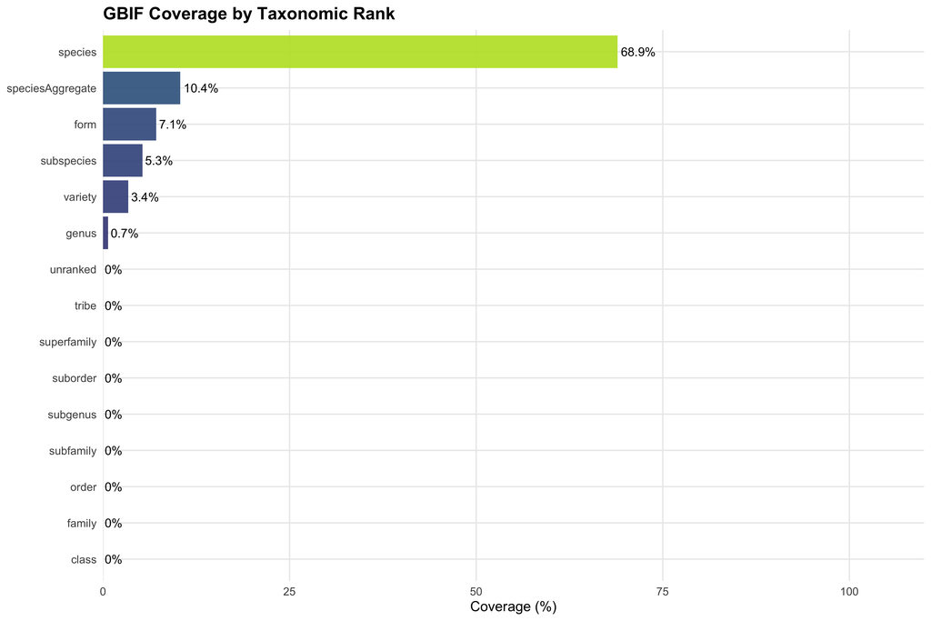

```r
tax_by_rank <- safe_read(here(p_tables, "overview_taxonomic_by_rank.csv"))

if (!is.null(tax_by_rank) && nrow(tax_by_rank) > 0) {
  rank_plot <- tax_by_rank |>
    filter(n_ref_total >= 10) |>
    arrange(desc(n_ref_total)) |>
    slice_head(n = 15)

  if (nrow(rank_plot) > 0) {
    ggplot(rank_plot, aes(x = fct_reorder(taxonRank, pct_coverage),
                           y = pct_coverage, fill = pct_coverage)) +
      geom_col(alpha = 0.9) +
      geom_text(aes(label = paste0(round(pct_coverage, 1), "%")), hjust = -0.1, size = 4) +
      coord_flip() +
      scale_fill_viridis_c(option = "viridis", begin = 0.2, end = 0.9) +
      scale_y_continuous(limits = c(0, 110), expand = expansion(mult = c(0, 0))) +
      labs(title = "GBIF Coverage by Taxonomic Rank", x = NULL, y = "Coverage (%)") +
      theme(legend.position = "none")
  }
}
```

## 1.3 Orders by Kingdom: Backbone vs GBIF Coverage

This section shows all orders in the backbone grouped by class, where:

- **Bar length** = total number of species in the backbone for that order
- **Green portion** = species found in GBIF
- **Blue portion** = species missing from GBIF

```r
# Load the match summary which has species-level matching info
match_summary <- safe_read(here(p_gaps, "taxonomic_match_summary.csv"))

order_coverage <- NULL

if (!is.null(match_summary) && nrow(match_summary) > 0 && "order" %in% names(match_summary)) {
  # Summarize by order: count species in backbone and in GBIF

  order_coverage <- match_summary |>
    filter(!is.na(order), order != "") |>
    group_by(across(any_of(c("kingdom", "phylum", "class", "order")))) |>
    summarise(
      n_species_backbone = n(),
      n_species_gbif = sum(matched_any, na.rm = TRUE),
      n_species_missing = n_species_backbone - n_species_gbif,
      pct_coverage = round(100 * n_species_gbif / n_species_backbone, 1),
      .groups = "drop"
    )

  cat(glue("**Total orders in backbone**: {nrow(order_coverage)}\n\n"))
  cat(glue("**Total species in backbone**: {comma(sum(order_coverage$n_species_backbone))}\n\n"))
  cat(glue("**Species found in GBIF**: {comma(sum(order_coverage$n_species_gbif))} ({round(100 * sum(order_coverage$n_species_gbif) / sum(order_coverage$n_species_backbone), 1)}%)\n\n"))
}
```

```
## **Total orders in backbone**: 1093
## **Total species in backbone**: 108,971
## **Species found in GBIF**: 53,092 (48.7%)
```

```r
# Function to create the stacked bar plot for a kingdom (absolute numbers)
plot_kingdom_orders <- function(data, kingdom_name, n_top_classes = 12) {
  if (is.null(data) || nrow(data) == 0) {
    return(NULL)
  }

  # Reshape to long format for stacking
  plot_data <- data |>
    select(class, order, n_species_gbif, n_species_missing) |>
    pivot_longer(
      cols = c(n_species_gbif, n_species_missing),
      names_to = "status",
      values_to = "n_species"
    ) |>
    mutate(
      status = factor(
        status,
        levels = c("n_species_missing", "n_species_gbif"),
        labels = c("Missing from GBIF", "In GBIF")
      )
    )

  # Get top classes by total species
  top_classes <- data |>
    group_by(class) |>
    summarise(total = sum(n_species_backbone), .groups = "drop") |>
    arrange(desc(total)) |>
    slice_head(n = n_top_classes) |>
    pull(class)

  plot_data <- plot_data |>
    filter(class %in% top_classes)

  # Calculate total species per order for sorting
  order_totals <- data |>
    filter(class %in% top_classes) |>
    group_by(class, order) |>
    summarise(total = sum(n_species_backbone), .groups = "drop")

  plot_data <- plot_data |>
    left_join(order_totals, by = c("class", "order"))

  # Create plot
  ggplot(plot_data, aes(x = reorder(order, total), y = n_species, fill = status)) +
    geom_col(alpha = 0.9, width = 0.8) +
    coord_flip() +
    facet_wrap(~class, scales = "free_y", ncol = 3) +
    scale_fill_manual(
      values = c("In GBIF" = "#2A9D8F", "Missing from GBIF" = "#457B9D"),
      name = NULL
    ) +
    scale_y_continuous(labels = comma, expand = expansion(mult = c(0, 0.05))) +
    labs(
      title = glue("{kingdom_name}: Species Coverage by Order (Absolute)"),
      subtitle = "Bar length = species in backbone | Green = in GBIF | Blue = missing",
      x = NULL,
      y = "Number of Species"
    ) +
    theme(
      legend.position = "bottom",
      strip.text = element_text(size = 9, face = "bold"),
      axis.text.y = element_text(size = 6),
      panel.spacing = unit(0.5, "lines")
    )
}

# Function to create percentage bar plot for a kingdom
plot_kingdom_orders_pct <- function(data, kingdom_name, n_top_classes = 12) {
  if (is.null(data) || nrow(data) == 0) {
    return(NULL)
  }

  # Get top classes by total species
  top_classes <- data |>
    group_by(class) |>
    summarise(total = sum(n_species_backbone), .groups = "drop") |>
    arrange(desc(total)) |>
    slice_head(n = n_top_classes) |>
    pull(class)

  # Calculate percentages
  plot_data <- data |>
    filter(class %in% top_classes) |>
    mutate(
      pct_gbif = 100 * n_species_gbif / n_species_backbone,
      pct_missing = 100 * n_species_missing / n_species_backbone
    ) |>
    select(class, order, n_species_backbone, pct_gbif, pct_missing) |>
    pivot_longer(
      cols = c(pct_gbif, pct_missing),
      names_to = "status",
      values_to = "pct"
    ) |>
    mutate(
      status = factor(
        status,
        levels = c("pct_missing", "pct_gbif"),
        labels = c("Missing from GBIF", "In GBIF")
      )
    )

  # Create plot - sort by coverage percentage (pct_gbif)
  order_pct <- data |>
    filter(class %in% top_classes) |>
    select(class, order, pct_coverage)

  plot_data <- plot_data |>
    left_join(order_pct, by = c("class", "order"))

  ggplot(plot_data, aes(x = reorder(order, pct_coverage), y = pct, fill = status)) +
    geom_col(alpha = 0.9, width = 0.8, position = "stack") +
    coord_flip() +
    facet_wrap(~class, scales = "free_y", ncol = 3) +
    scale_fill_manual(
      values = c("In GBIF" = "#2A9D8F", "Missing from GBIF" = "#457B9D"),
      name = NULL
    ) +
    scale_y_continuous(
      limits = c(0, 100),
      breaks = c(0, 25, 50, 75, 100),
      expand = expansion(mult = c(0, 0))
    ) +
    labs(
      title = glue("{kingdom_name}: Species Coverage by Order (Percentage)"),
      subtitle = "All orders = 100% of backbone species | Green = % in GBIF | Blue = % missing",
      x = NULL,
      y = "Coverage (%)"
    ) +
    theme(
      legend.position = "bottom",
      strip.text = element_text(size = 9, face = "bold"),
      axis.text.y = element_text(size = 6),
      panel.spacing = unit(0.5, "lines")
    )
}
```

### Animalia

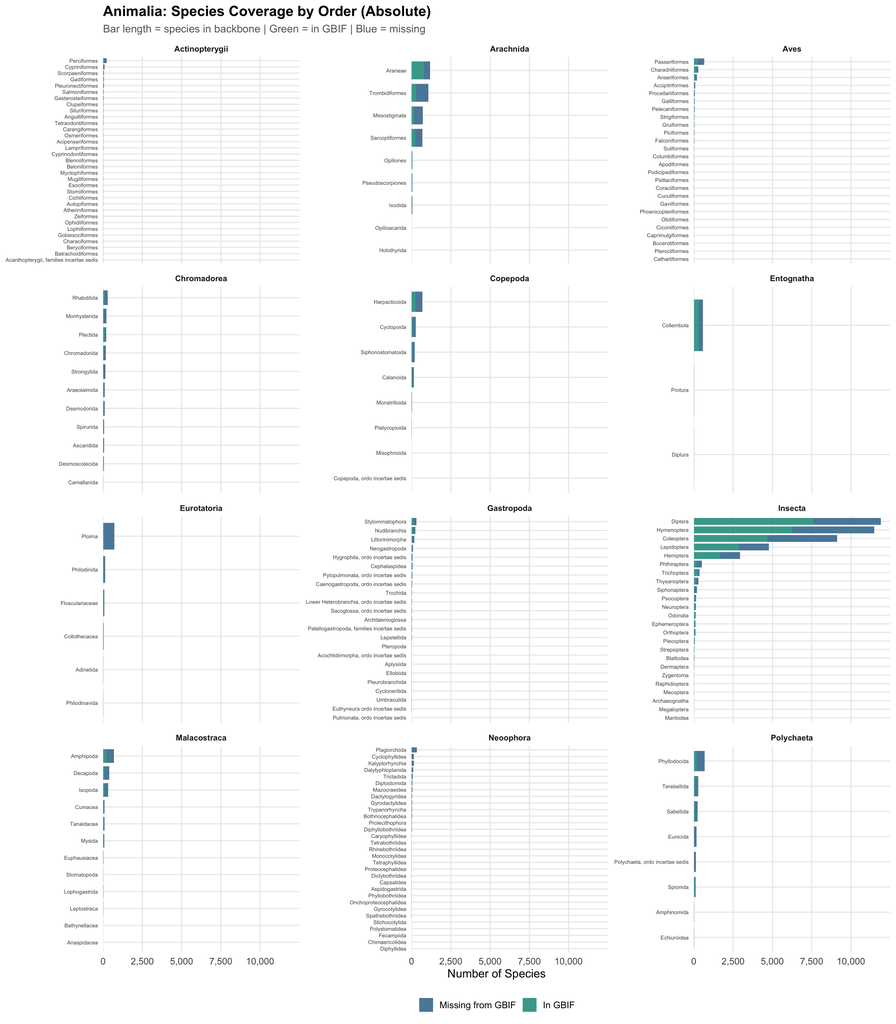

```r
if (!is.null(order_coverage) && "kingdom" %in% names(order_coverage)) {
  animalia <- order_coverage |>
    filter(kingdom == "Animalia", !is.na(class), class != "")

  if (nrow(animalia) > 0) {
    print(plot_kingdom_orders(animalia, "Animalia", n_top_classes = 12))
  } else {
    cat("No Animalia data found.\n")
  }
}
```

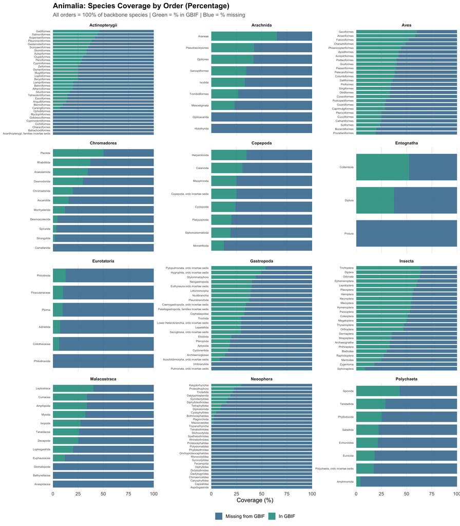

```r
if (exists("animalia") && nrow(animalia) > 0) {
  print(plot_kingdom_orders_pct(animalia, "Animalia", n_top_classes = 12))
}
```

```r
if (exists("animalia") && nrow(animalia) > 0) {
  animalia |>
    group_by(class) |>
    summarise(
      n_orders = n(),
      species_backbone = sum(n_species_backbone),
      species_gbif = sum(n_species_gbif),
      species_missing = sum(n_species_missing),
      pct_coverage = round(100 * species_gbif / species_backbone, 1),
      .groups = "drop"
    ) |>
    arrange(desc(species_backbone)) |>
    kable(caption = "Animalia: Species Coverage by Class")
}
```

Animalia: Species Coverage by Class

| class | n_orders | species_backbone | species_gbif | species_missing | pct_coverage |
| --- | --- | --- | --- | --- | --- |
| Insecta | 24 | 42324 | 23960 | 18364 | 56.6 |
| Arachnida | 9 | 3802 | 1515 | 2287 | 39.8 |
| Malacostraca | 12 | 1682 | 497 | 1185 | 29.5 |
| Aves | 26 | 1664 | 699 | 965 | 42.0 |
| Polychaeta | 8 | 1634 | 409 | 1225 | 25.0 |
| Chromadorea | 11 | 1392 | 348 | 1044 | 25.0 |
| Copepoda | 8 | 1346 | 396 | 950 | 29.4 |
| Gastropoda | 23 | 1260 | 488 | 772 | 38.7 |
| Neoophora | 31 | 1260 | 119 | 1141 | 9.4 |
| Eurotatoria | 6 | 967 | 95 | 872 | 9.8 |
| Actinopterygii | 33 | 749 | 212 | 537 | 28.3 |
| Entognatha | 3 | 594 | 306 | 288 | 51.5 |
| Clitellata | 8 | 570 | 279 | 291 | 48.9 |
| Enoplea | 5 | 455 | 71 | 384 | 15.6 |
| Bivalvia | 14 | 442 | 182 | 260 | 41.2 |
| Hydrozoa | 10 | 439 | 134 | 305 | 30.5 |
| Ostracoda | 4 | 411 | 81 | 330 | 19.7 |
| Mammalia | 9 | 339 | 117 | 222 | 34.5 |
| Demospongiae | 15 | 308 | 101 | 207 | 32.8 |
| Gymnolaemata | 2 | 285 | 92 | 193 | 32.3 |
| Branchiopoda | 8 | 223 | 66 | 157 | 29.6 |
| Anthozoa | 8 | 176 | 50 | 126 | 28.4 |
| Eutardigrada | 2 | 162 | 31 | 131 | 19.1 |
| Diplopoda | 7 | 138 | 51 | 87 | 37.0 |
| Acoelomorpha, classis incertae sedis | 2 | 136 | 63 | 73 | 46.3 |
| Thecostraca | 6 | 105 | 27 | 78 | 25.7 |
| Polycladidea | 3 | 98 | 27 | 71 | 27.6 |
| Chondrichthyes | 10 | 93 | 19 | 74 | 20.4 |
| Chilopoda | 4 | 76 | 36 | 40 | 47.4 |
| Hoplonemertea | 2 | 66 | 21 | 45 | 31.8 |
| Asteroidea | 6 | 64 | 22 | 42 | 34.4 |
| Cephalopoda | 6 | 61 | 15 | 46 | 24.6 |
| Palaeacanthocephala | 2 | 59 | 13 | 46 | 22.0 |
| Stenolaemata | 1 | 59 | 22 | 37 | 37.3 |
| Holothuroidea | 4 | 57 | 15 | 42 | 26.3 |
| Heterotardigrada | 2 | 54 | 7 | 47 | 13.0 |
| Macrostomorpha | 3 | 54 | 29 | 25 | 53.7 |
| Ophiuroidea | 2 | 52 | 22 | 30 | 42.3 |
| Amphibia | 2 | 49 | 15 | 34 | 30.6 |
| Pilidiophora | 1 | 46 | 16 | 30 | 34.8 |
| Entoprocta, ordines incertae sedis | 1 | 43 | 16 | 27 | 37.2 |
| Pycnogonida | 1 | 43 | 10 | 33 | 23.3 |
| Echinoidea | 4 | 40 | 13 | 27 | 32.5 |
| Palaeonemertea | 4 | 40 | 14 | 26 | 35.0 |
| Calcarea | 2 | 31 | 11 | 20 | 35.5 |
| Polyplacophora | 2 | 30 | 12 | 18 | 40.0 |
| Sipunculidea | 2 | 26 | 7 | 19 | 26.9 |
| Pauropoda | 1 | 25 | 7 | 18 | 28.0 |
| Scyphozoa | 3 | 23 | 6 | 17 | 26.1 |
| Sagittoidea | 2 | 22 | 4 | 18 | 18.2 |
| Scaphopoda | 2 | 19 | 5 | 14 | 26.3 |
| Gordioida | 3 | 18 | 2 | 16 | 11.1 |
| Solenogastres | 3 | 17 | 1 | 16 | 5.9 |
| Phylactolaemata | 1 | 16 | 4 | 12 | 25.0 |
| Tentaculata | 2 | 16 | 5 | 11 | 31.2 |
| Articulata | 1 | 15 | 4 | 11 | 26.7 |
| Enteropneusta | 1 | 15 | 6 | 9 | 40.0 |
| Symphyla | 1 | 15 | 8 | 7 | 53.3 |
| Staurozoa | 1 | 14 | 3 | 11 | 21.4 |
| Caudofoveata | 1 | 12 | 3 | 9 | 25.0 |
| Crinoidea | 1 | 10 | 2 | 8 | 20.0 |
| Ichthyostraca | 2 | 10 | 2 | 8 | 20.0 |
| Priapulida, classis incertae sedis | 2 | 10 | 2 | 8 | 20.0 |
| Archiacanthocephala | 2 | 9 | 0 | 9 | 0.0 |
| Eoacanthocephala | 1 | 8 | 1 | 7 | 12.5 |
| Phascolosomatidea | 2 | 8 | 1 | 7 | 12.5 |
| Phoronida, classis incertae sedis | 1 | 8 | 4 | 4 | 50.0 |
| Petromyzontida | 1 | 7 | 3 | 4 | 42.9 |
| Inarticulata | 1 | 6 | 1 | 5 | 16.7 |
| Nuda | 1 | 6 | 3 | 3 | 50.0 |
| Pararotatoria | 1 | 6 | 0 | 6 | 0.0 |
| Xenoturbellida, classis incertae sedis | 1 | 5 | 1 | 4 | 20.0 |
| Eucycliophora | 1 | 4 | 0 | 4 | 0.0 |
| Graptolithoidea | 1 | 4 | 0 | 4 | 0.0 |
| Homoscleromorpha | 1 | 4 | 0 | 4 | 0.0 |
| Leptocardia | 1 | 4 | 1 | 3 | 25.0 |
| Merostomata | 1 | 4 | 0 | 4 | 0.0 |
| Myxini | 1 | 4 | 1 | 3 | 25.0 |
| Polypodiozoa | 1 | 4 | 0 | 4 | 0.0 |
| Tantulocarida | 1 | 2 | 0 | 2 | 0.0 |

### Plantae

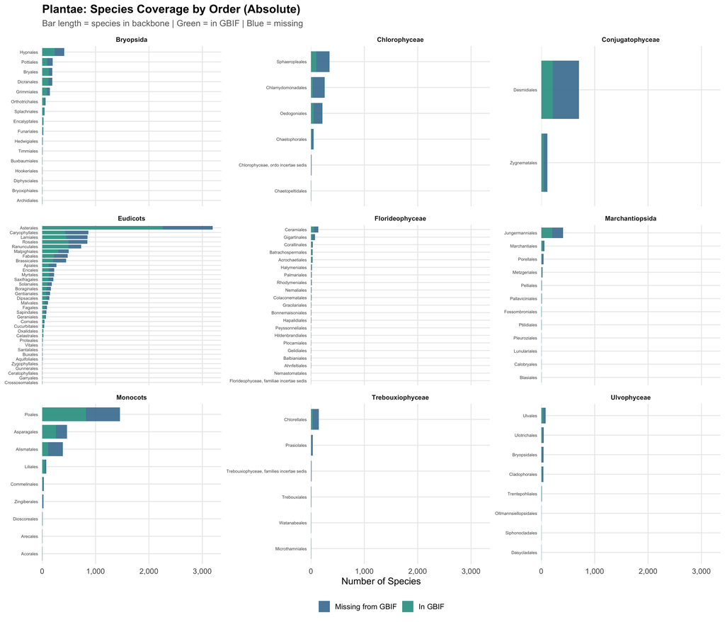

```r
if (!is.null(order_coverage) && "kingdom" %in% names(order_coverage)) {
  plantae <- order_coverage |>
    filter(kingdom == "Plantae", !is.na(class), class != "")

  if (nrow(plantae) > 0) {
    print(plot_kingdom_orders(plantae, "Plantae", n_top_classes = 9))
  } else {
    cat("No Plantae data found.\n")
  }
}
```

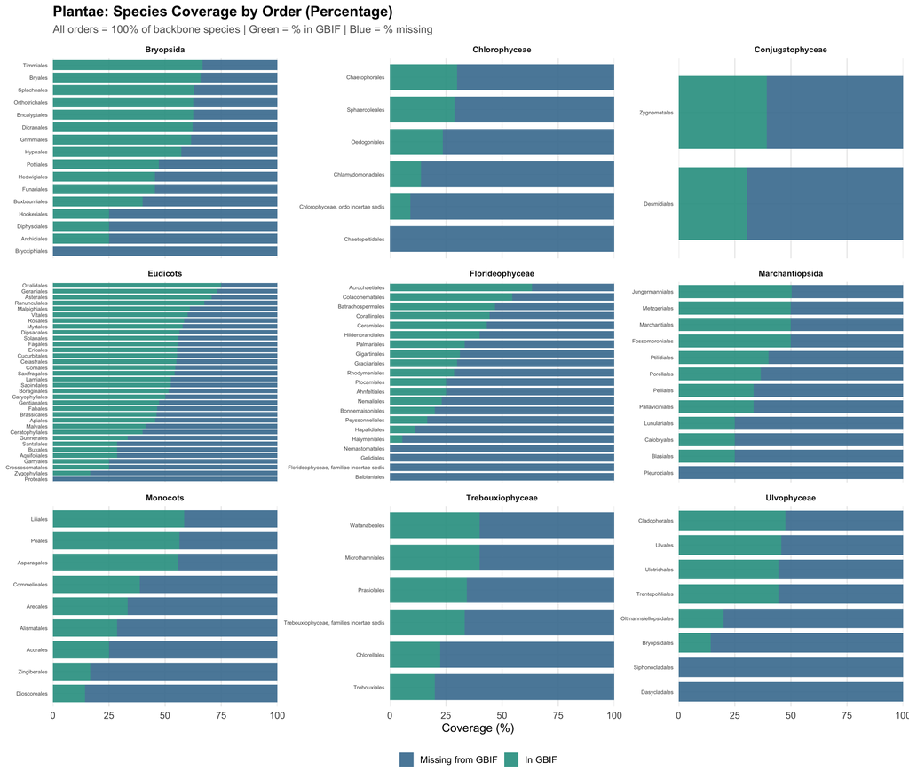

```r
if (exists("plantae") && nrow(plantae) > 0) {
  print(plot_kingdom_orders_pct(plantae, "Plantae", n_top_classes = 9))
}
```

```r
if (exists("plantae") && nrow(plantae) > 0) {
  plantae |>
    group_by(class) |>
    summarise(
      n_orders = n(),
      species_backbone = sum(n_species_backbone),
      species_gbif = sum(n_species_gbif),
      species_missing = sum(n_species_missing),
      pct_coverage = round(100 * species_gbif / species_backbone, 1),
      .groups = "drop"
    ) |>
    arrange(desc(species_backbone)) |>
    kable(caption = "Plantae: Species Coverage by Class")
}
```

Plantae: Species Coverage by Class

| class | n_orders | species_backbone | species_gbif | species_missing | pct_coverage |
| --- | --- | --- | --- | --- | --- |
| Eudicots | 34 | 9998 | 5955 | 4043 | 59.6 |
| Monocots | 9 | 2457 | 1256 | 1201 | 51.1 |
| Bryopsida | 16 | 1324 | 767 | 557 | 57.9 |
| Chlorophyceae | 6 | 889 | 203 | 686 | 22.8 |
| Conjugatophyceae | 2 | 817 | 259 | 558 | 31.7 |
| Marchantiopsida | 12 | 577 | 276 | 301 | 47.8 |
| Florideophyceae | 21 | 447 | 164 | 283 | 36.7 |
| Ulvophyceae | 8 | 227 | 87 | 140 | 38.3 |
| Trebouxiophyceae | 6 | 214 | 55 | 159 | 25.7 |
| Polypodiopsida | 5 | 175 | 72 | 103 | 41.1 |
| Pinopsida | 3 | 155 | 85 | 70 | 54.8 |
| Magnoliids | 4 | 89 | 22 | 67 | 24.7 |
| Sphagnopsida | 1 | 75 | 46 | 29 | 61.3 |
| Pyramimonadophyceae | 2 | 56 | 14 | 42 | 25.0 |
| Charophyceae | 1 | 53 | 35 | 18 | 66.0 |
| Lycopodiopsida | 3 | 45 | 17 | 28 | 37.8 |
| Polytrichopsida | 1 | 38 | 27 | 11 | 71.1 |
| Equisetopsida | 1 | 25 | 17 | 8 | 68.0 |
| Mamiellophyceae | 3 | 23 | 5 | 18 | 21.7 |
| Chlorodendrophyceae | 1 | 22 | 5 | 17 | 22.7 |
| Coleochaetophyceae | 2 | 22 | 6 | 16 | 27.3 |
| Ophioglossida | 2 | 21 | 9 | 12 | 42.9 |
| Andreaeopsida | 1 | 20 | 8 | 12 | 40.0 |
| Bangiophyceae | 2 | 20 | 6 | 14 | 30.0 |
| Pedinophyceae | 3 | 16 | 0 | 16 | 0.0 |
| Stylonematophyceae | 1 | 15 | 3 | 12 | 20.0 |
| Compsopogonophyceae | 1 | 13 | 4 | 9 | 30.8 |
| Klebsormidiophyceae | 1 | 13 | 3 | 10 | 23.1 |
| Anthocerotopsida | 2 | 12 | 4 | 8 | 33.3 |
| Cyanidiophyceae | 2 | 9 | 0 | 9 | 0.0 |
| Chlorophyta, classis incertae sedis | 1 | 8 | 0 | 8 | 0.0 |
| Glaucophyceae | 2 | 8 | 2 | 6 | 25.0 |
| Nephrophyceae | 1 | 8 | 3 | 5 | 37.5 |
| Tetraphidopsida | 1 | 8 | 4 | 4 | 50.0 |
| Rhodellophyceae | 2 | 6 | 1 | 5 | 16.7 |
| Porphyridiophyceae | 1 | 5 | 1 | 4 | 20.0 |
| Ginkgoopsida | 1 | 4 | 1 | 3 | 25.0 |
| Mesostigmatophyceae | 1 | 4 | 0 | 4 | 0.0 |
| Oedipodiopsida | 1 | 4 | 1 | 3 | 25.0 |
| Palmophyllophyceae | 2 | 2 | 0 | 2 | 0.0 |

### Fungi

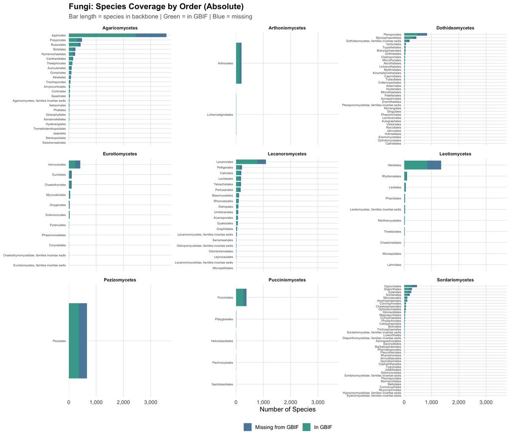

```r
if (!is.null(order_coverage) && "kingdom" %in% names(order_coverage)) {
  fungi <- order_coverage |>
    filter(kingdom == "Fungi", !is.na(class), class != "")

  if (nrow(fungi) > 0) {
    print(plot_kingdom_orders(fungi, "Fungi", n_top_classes = 9))
  } else {
    cat("No Fungi data found.\n")
  }
}
```

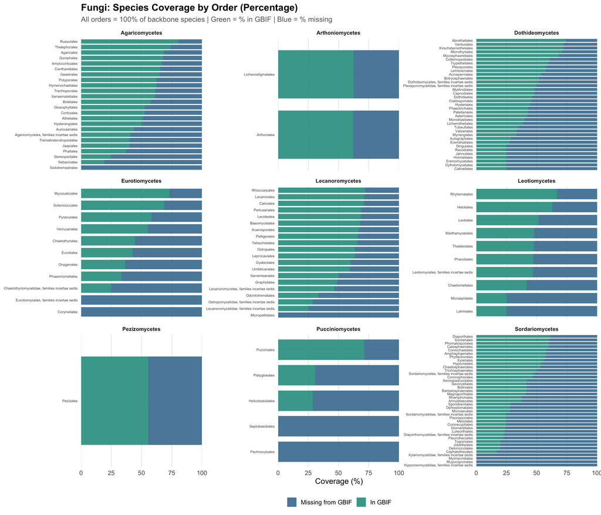

```r
if (exists("fungi") && nrow(fungi) > 0) {
  print(plot_kingdom_orders_pct(fungi, "Fungi", n_top_classes = 9))
}
```

```r
if (exists("fungi") && nrow(fungi) > 0) {
  fungi |>
    group_by(class) |>
    summarise(
      n_orders = n(),
      species_backbone = sum(n_species_backbone),
      species_gbif = sum(n_species_gbif),
      species_missing = sum(n_species_missing),
      pct_coverage = round(100 * species_gbif / species_backbone, 1),
      .groups = "drop"
    ) |>
    arrange(desc(species_backbone)) |>
    kable(caption = "Fungi: Species Coverage by Class")
}
```

Fungi: Species Coverage by Class

| class | n_orders | species_backbone | species_gbif | species_missing | pct_coverage |
| --- | --- | --- | --- | --- | --- |
| Agaricomycetes | 24 | 5818 | 3879 | 1939 | 66.7 |
| Lecanoromycetes | 20 | 2695 | 1824 | 871 | 67.7 |
| Dothideomycetes | 35 | 2093 | 1207 | 886 | 57.7 |
| Sordariomycetes | 39 | 2013 | 1022 | 991 | 50.8 |
| Leotiomycetes | 10 | 1648 | 1011 | 637 | 61.3 |
| Eurotiomycetes | 11 | 770 | 403 | 367 | 52.3 |
| Pezizomycetes | 1 | 662 | 368 | 294 | 55.6 |
| Pucciniomycetes | 5 | 412 | 281 | 131 | 68.2 |
| Arthoniomycetes | 2 | 211 | 131 | 80 | 62.1 |
| Lichinomycetes | 6 | 197 | 117 | 80 | 59.4 |
| Laboulbeniomycetes | 3 | 186 | 94 | 92 | 50.5 |
| Ustilaginomycetes | 2 | 163 | 106 | 57 | 65.0 |
| Microsporidiidea | 2 | 132 | 3 | 129 | 2.3 |
| Ascomycota, ordines incertae sedis | 1 | 123 | 49 | 74 | 39.8 |
| Tremellomycetes | 6 | 122 | 50 | 72 | 41.0 |
| Exobasidiomycetes | 5 | 112 | 71 | 41 | 63.4 |
| Microbotryomycetes | 5 | 77 | 39 | 38 | 50.6 |
| Pezizomycotina, ordines incertae sedis | 3 | 64 | 33 | 31 | 51.6 |
| Mucoromycetes | 1 | 62 | 27 | 35 | 43.5 |
| Dacrymycetes | 1 | 52 | 31 | 21 | 59.6 |
| Taphrinomycetes | 1 | 51 | 37 | 14 | 72.5 |
| Orbiliomycetes | 1 | 45 | 24 | 21 | 53.3 |
| Glomeromycetes | 4 | 38 | 4 | 34 | 10.5 |
| Entomophthoromycetes | 1 | 36 | 12 | 24 | 33.3 |
| Chytridiomycetes | 6 | 32 | 2 | 30 | 6.2 |
| Rhizophydiomycetes | 1 | 21 | 2 | 19 | 9.5 |
| Dipodascomycetes | 1 | 20 | 4 | 16 | 20.0 |
| Physodermatomycetes | 1 | 19 | 12 | 7 | 63.2 |
| Pichiomycetes | 1 | 16 | 5 | 11 | 31.2 |
| Synchytriomycetes | 1 | 16 | 12 | 4 | 75.0 |
| Atractiellomycetes | 1 | 12 | 3 | 9 | 25.0 |
| Blastocladiomycetes | 3 | 12 | 0 | 12 | 0.0 |
| Saccharomycetes | 2 | 12 | 1 | 11 | 8.3 |
| Agaricostilbomycetes | 1 | 10 | 2 | 8 | 20.0 |
| Malasseziomycetes | 1 | 10 | 4 | 6 | 40.0 |
| Entorrhizomycetes | 1 | 9 | 3 | 6 | 33.3 |
| Zoopagomycetes | 1 | 9 | 0 | 9 | 0.0 |
| Endogonomycetes | 1 | 8 | 3 | 5 | 37.5 |
| Olpidiomycetes | 1 | 8 | 1 | 7 | 12.5 |
| Basidiomycota, ordines incertae sedis | 1 | 7 | 0 | 7 | 0.0 |
| Cystobasidiomycetes | 2 | 7 | 1 | 6 | 14.3 |
| Spiculogloeomycetes | 1 | 7 | 0 | 7 | 0.0 |
| Umbelopsidomycetes | 1 | 7 | 3 | 4 | 42.9 |
| Wallemiomycetes | 1 | 7 | 2 | 5 | 28.6 |
| Cladochytriomycetes | 1 | 6 | 0 | 6 | 0.0 |
| Hyaloraphidiomycetes | 1 | 6 | 0 | 6 | 0.0 |
| Archaeorhizomycetes | 1 | 5 | 2 | 3 | 40.0 |
| Basidiobolomycetes | 1 | 5 | 1 | 4 | 20.0 |
| Monoblepharidomycetes | 1 | 5 | 0 | 5 | 0.0 |
| Pneumocystomycetes | 1 | 5 | 0 | 5 | 0.0 |
| Rhizophlyctidomycetes | 1 | 5 | 1 | 4 | 20.0 |
| Alloascoideomycetes | 1 | 4 | 0 | 4 | 0.0 |
| Archaeosporomycetes | 1 | 4 | 0 | 4 | 0.0 |
| Bartheletiomycetes | 1 | 4 | 1 | 3 | 25.0 |
| Kickxellomycetes | 1 | 4 | 1 | 3 | 25.0 |
| Lobulomycetes | 1 | 4 | 1 | 3 | 25.0 |
| Neolectomycetes | 1 | 4 | 1 | 3 | 25.0 |
| Neozygitomycetes | 1 | 4 | 0 | 4 | 0.0 |
| Paraglomeromycetes | 1 | 4 | 0 | 4 | 0.0 |
| Pucciniomycotina, ordines incerta sedis | 1 | 4 | 1 | 3 | 25.0 |
| Rudimicrosporea | 1 | 4 | 0 | 4 | 0.0 |
| Schizosaccharomycetes | 1 | 4 | 1 | 3 | 25.0 |
| Neocallimastigomycetes | 1 | 3 | 0 | 3 | 0.0 |
| Rozellomycota, ordines incertae sedis | 1 | 3 | 0 | 3 | 0.0 |
| Asellariomycetes | 1 | 2 | 0 | 2 | 0.0 |

### Other Kingdoms

[figure not shown]

```r
if (!is.null(order_coverage) && "kingdom" %in% names(order_coverage)) {
  other <- order_coverage |>
    filter(!kingdom %in% c("Animalia", "Plantae", "Fungi"),
           !is.na(kingdom), kingdom != "",
           !is.na(class), class != "")

  if (nrow(other) > 0) {
    # For other kingdoms, facet by kingdom instead of class
    plot_data <- other |>
      select(kingdom, class, order, n_species_gbif, n_species_missing, n_species_backbone) |>
      pivot_longer(
        cols = c(n_species_gbif, n_species_missing),
        names_to = "status",
        values_to = "n_species"
      ) |>
      mutate(
        status = factor(
          status,
          levels = c("n_species_missing", "n_species_gbif"),
          labels = c("Missing from GBIF", "In GBIF")
        ),
        label = paste0(class, ": ", order)
      )

    ggplot(plot_data, aes(x = reorder(label, n_species_backbone), y = n_species, fill = status)) +
      geom_col(alpha = 0.9, width = 0.8) +
      coord_flip() +
      facet_wrap(~kingdom, scales = "free_y", ncol = 2) +
      scale_fill_manual(
        values = c("In GBIF" = "#2A9D8F", "Missing from GBIF" = "#457B9D"),
        name = NULL
      ) +
      scale_y_continuous(labels = comma, expand = expansion(mult = c(0, 0.05))) +
      labs(
        title = "Other Kingdoms: Species Coverage by Order",
        subtitle = "Bar length = species in backbone | Green = in GBIF | Blue = missing",
        x = NULL, y = "Number of Species"
      ) +
      theme(
        legend.position = "bottom",
        strip.text = element_text(size = 10, face = "bold"),
        axis.text.y = element_text(size = 7)
      )
  } else {
    cat("No other kingdoms found.\n")
  }
}
```

### Summary by Kingdom

```r
if (!is.null(order_coverage) && "kingdom" %in% names(order_coverage)) {
  order_coverage |>
    group_by(kingdom) |>
    summarise(
      n_orders = n(),
      species_backbone = sum(n_species_backbone),
      species_gbif = sum(n_species_gbif),
      species_missing = sum(n_species_missing),
      pct_coverage = round(100 * species_gbif / species_backbone, 1),
      .groups = "drop"
    ) |>
    arrange(desc(species_backbone)) |>
    kable(caption = "Species Coverage Summary by Kingdom")
}
```

Species Coverage Summary by Kingdom

| kingdom | n_orders | species_backbone | species_gbif | species_missing | pct_coverage |
| --- | --- | --- | --- | --- | --- |
| Animalia | 421 | 64869 | 30962 | 33907 | 47.7 |
| Fungi | 242 | 18147 | 10904 | 7243 | 60.1 |
| Plantae | 169 | 17924 | 9423 | 8501 | 52.6 |
| Chromista | 180 | 5905 | 1228 | 4677 | 20.8 |
| Protozoa | 40 | 1021 | 316 | 705 | 31.0 |
| Bacteria | 30 | 1003 | 259 | 744 | 25.8 |
| Viruses | 11 | 102 | 0 | 102 | 0.0 |

# 2. Threatened Species

This section analyzes coverage of threatened species from backbone in GBIF data.

```r
# Use match_summary which we know has the data
# Check for threat status columns - could be named differently

threatened_summary <- NULL
has_threat_data <- FALSE

if (!is.null(match_summary) && nrow(match_summary) > 0) {

  # Look for threat status column - try different possible names
  threat_col <- NULL
  possible_threat_cols <- c("threatStatus", "redlistCategory", "redlist_category",
                            "swedish_redlist_category", "dyntaxa_redlist_category",
                            "RedlistCategory", "IUCN_category")

  for (col in possible_threat_cols) {
    if (col %in% names(match_summary)) {
      threat_col <- col
      break
    }
  }

  if (!is.null(threat_col)) {
    # Check if there's actual data in the column
    threat_values <- match_summary[[threat_col]]
    non_empty <- sum(!is.na(threat_values) & threat_values != "" & str_trim(threat_values) != "")

    if (non_empty > 0) {
      has_threat_data <- TRUE

      # Rename to threatStatus for consistency
      threatened_summary <- match_summary |>
        mutate(threatStatus = .data[[threat_col]]) |>
        filter(!is.na(threatStatus), threatStatus != "", str_trim(threatStatus) != "")

      cat(glue("**Total taxa with threat status in backbone**: {comma(nrow(threatened_summary))}\n\n"))
      cat(glue("**Found in GBIF**: {comma(sum(threatened_summary$matched_any, na.rm = TRUE))}\n\n"))
      cat(glue("**Missing from GBIF**: {comma(sum(!threatened_summary$matched_any, na.rm = TRUE))}\n\n"))
    }
  }

  if (!has_threat_data) {
    cat("
<div style='background-color: #fff3cd; border: 1px solid #ffc107; padding: 15px; border-radius: 5px; margin: 20px 0;'>
<h4 style='color: #856404; margin-top: 0;'>⚠️ No Threat Status Data Available</h4>
<p>The national backbone does not contain Red List threat categories (CR, EN, VU, NT, LC, etc.).</p>
<p><strong>To enable threatened species analysis:</strong></p>
<ol>
<li>Obtain the National Red List data (Artdatabanken)</li>
<li>Join it to the backbone backbone in script 03 (taxa_reference preparation)</li>
<li>Ensure the joined data has a column named <code>threatStatus_redlist</code> or <code>threatStatus_backbone</code></li>
<li>Re-run script 09 to regenerate the taxonomic match summary</li>
</ol>
</div>
")
  }
} else {
  cat("match_summary not available. Please ensure section 1.3 ran successfully.\n")
}
```

```
## **Total taxa with threat status in backbone**: 5,475
## **Found in GBIF**: 5,075
## **Missing from GBIF**: 400
```

```r
if (!has_threat_data) {
  cat("
## 2.1 Coverage by Threat Status
*Skipped - no threat status data available*

## 2.2 Missing Threatened Taxa
*Skipped - no threat status data available*

## 2.3 Missing Taxa by Taxonomic Group
*Skipped - no threat status data available*

## 2.4 Threatened Species with Poor Spatial Coverage
*Skipped - no threat status data available*
")
}
```

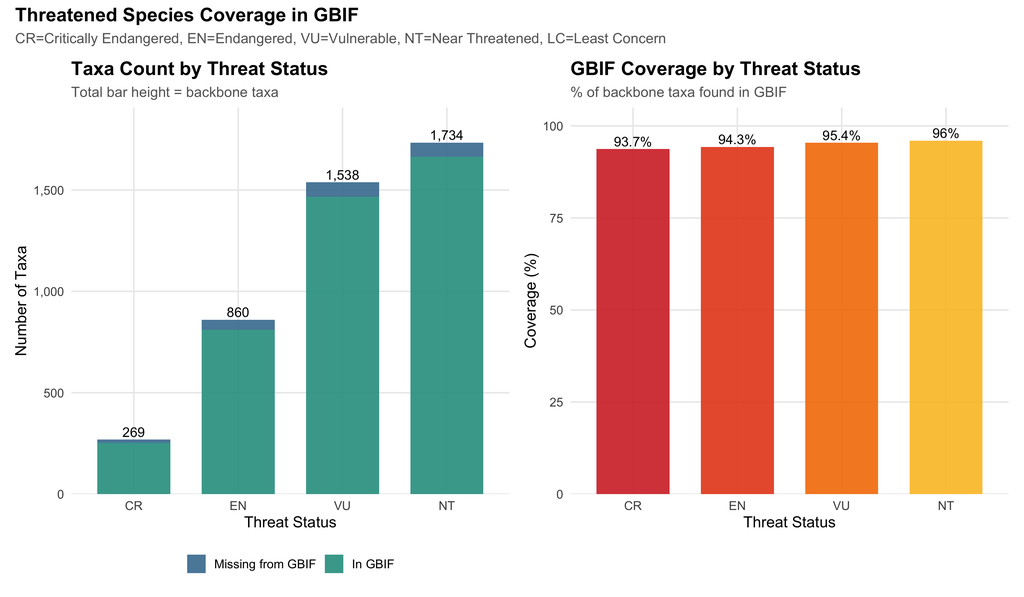

```r
# Only runs if has_threat_data is TRUE
if (!is.null(threatened_summary) && nrow(threatened_summary) > 0) {
  # Summarize by threat status
  threat_stats <- threatened_summary |>
    group_by(threatStatus) |>
    summarise(
      n_backbone = n(),
      n_gbif = sum(matched_any, na.rm = TRUE),
      n_missing = n_backbone - n_gbif,
      pct_coverage = round(100 * n_gbif / n_backbone, 1),
      .groups = "drop"
    ) |>
    filter(threatStatus %in% c("CR", "EN", "VU", "NT", "LC")) |>
    mutate(threatStatus = factor(threatStatus, levels = c("CR", "EN", "VU", "NT", "LC")))

  if (nrow(threat_stats) > 0) {
    # Plot 1: Absolute numbers (stacked bar)
    threat_long <- threat_stats |>
      select(threatStatus, n_gbif, n_missing) |>
      pivot_longer(cols = c(n_gbif, n_missing), names_to = "status", values_to = "count") |>
      mutate(
        status = factor(status,
                        levels = c("n_missing", "n_gbif"),
                        labels = c("Missing from GBIF", "In GBIF"))
      )

    p1 <- ggplot(threat_long, aes(x = threatStatus, y = count, fill = status)) +
      geom_col(alpha = 0.9, width = 0.7) +
      geom_text(data = threat_stats,
                aes(x = threatStatus, y = n_backbone, label = comma(n_backbone), fill = NULL),
                vjust = -0.3, size = 4) +
      scale_fill_manual(
        values = c("In GBIF" = "#2A9D8F", "Missing from GBIF" = "#457B9D"),
        name = NULL
      ) +
      scale_y_continuous(expand = expansion(mult = c(0, 0.1)), labels = comma) +
      labs(
        title = "Taxa Count by Threat Status",
        subtitle = "Total bar height = backbone taxa",
        x = "Threat Status", y = "Number of Taxa"
      ) +
      theme(legend.position = "bottom")

    # Plot 2: Coverage percentage
    p2 <- ggplot(threat_stats, aes(x = threatStatus, y = pct_coverage, fill = threatStatus)) +
      geom_col(alpha = 0.9, width = 0.7) +
      geom_text(aes(label = paste0(pct_coverage, "%")), vjust = -0.3, size = 4) +
      scale_fill_manual(values = threat_colors) +
      scale_y_continuous(limits = c(0, 105), expand = expansion(mult = c(0, 0))) +
      labs(
        title = "GBIF Coverage by Threat Status",
        subtitle = "% of backbone taxa found in GBIF",
        x = "Threat Status", y = "Coverage (%)"
      ) +
      theme(legend.position = "none")

    print(p1 + p2 + plot_annotation(
      title = "Threatened Species Coverage in GBIF",
      subtitle = "CR=Critically Endangered, EN=Endangered, VU=Vulnerable, NT=Near Threatened, LC=Least Concern"
    ))
  }
}
```

```r
if (exists("threat_stats") && !is.null(threat_stats) && nrow(threat_stats) > 0) {
  threat_stats |>
    select(threatStatus, n_backbone, n_gbif, n_missing, pct_coverage) |>
    kable(
      caption = "Threatened Species Coverage Summary",
      col.names = c("Threat Status", "In Backbone", "In GBIF", "Missing", "Coverage %")
    )
}
```

Threatened Species Coverage Summary

| Threat Status | In Backbone | In GBIF | Missing | Coverage % |
| --- | --- | --- | --- | --- |
| CR | 269 | 252 | 17 | 93.7 |
| EN | 860 | 811 | 49 | 94.3 |
| NT | 1734 | 1665 | 69 | 96.0 |
| VU | 1538 | 1467 | 71 | 95.4 |

```
## **206 threatened taxa (CR/EN/VU/NT)** are missing from GBIF.
```

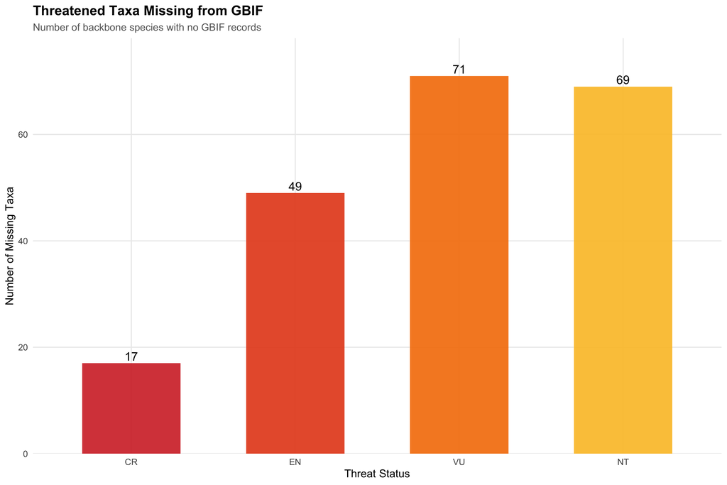

```r
if (!is.null(threatened_summary) && nrow(threatened_summary) > 0) {
  # Get missing threatened taxa
  missing_threatened <- threatened_summary |>
    filter(!matched_any) |>
    filter(threatStatus %in% c("CR", "EN", "VU", "NT"))

  if (nrow(missing_threatened) > 0) {
    cat(glue("**{comma(nrow(missing_threatened))} threatened taxa (CR/EN/VU/NT)** are missing from GBIF.\n\n"))

    # Summary by threat status
    missing_by_threat <- missing_threatened |>
      group_by(threatStatus) |>
      summarise(n = n(), .groups = "drop") |>
      mutate(threatStatus = factor(threatStatus, levels = c("CR", "EN", "VU", "NT")))

    # Bar plot of missing taxa
    print(ggplot(missing_by_threat, aes(x = threatStatus, y = n, fill = threatStatus)) +
      geom_col(alpha = 0.9, width = 0.6) +
      geom_text(aes(label = comma(n)), vjust = -0.3, size = 5) +
      scale_fill_manual(values = threat_colors) +
      scale_y_continuous(expand = expansion(mult = c(0, 0.1))) +
      labs(
        title = "Threatened Taxa Missing from GBIF",
        subtitle = "Number of backbone species with no GBIF records",
        x = "Threat Status", y = "Number of Missing Taxa"
      ) +
      theme(legend.position = "none"))
  } else {
    cat("All threatened taxa are represented in GBIF!\n")
  }
}
```

```r
if (exists("missing_threatened") && !is.null(missing_threatened) && nrow(missing_threatened) > 0) {
  # Get CR and EN taxa
  cr_en <- missing_threatened |>
    filter(threatStatus %in% c("CR", "EN")) |>
    arrange(threatStatus, kingdom, phylum, class, order, family, scientificName)

  if (nrow(cr_en) > 0) {
    cat("\n### Complete List of Missing CR/EN Taxa\n\n")
    cat(glue("**Total: {nrow(cr_en)} taxa** ({sum(cr_en$threatStatus == 'CR')} CR, {sum(cr_en$threatStatus == 'EN')} EN)\n\n"))

    # Group by kingdom
    kingdoms <- unique(cr_en$kingdom)
    kingdoms <- kingdoms[!is.na(kingdoms) & kingdoms != ""]

    for (k in kingdoms) {
      k_data <- cr_en |> filter(kingdom == k)
      cat(glue("\n## {k} ({nrow(k_data)} taxa)\n\n"))

      # Group by phylum within kingdom
      phyla <- unique(k_data$phylum)
      phyla <- phyla[!is.na(phyla) & phyla != ""]

      for (p in phyla) {
        p_data <- k_data |> filter(phylum == p)
        cat(glue("\n### {p} ({nrow(p_data)} taxa)\n\n"))

        # Group by class within phylum
        classes <- unique(p_data$class)
        classes <- classes[!is.na(classes) & classes != ""]

        for (cl in classes) {
          cl_data <- p_data |> filter(class == cl)
          cat(glue("\n#### {cl} ({nrow(cl_data)} taxa)\n\n"))

          # Group by order within class
          orders <- unique(cl_data$order)
          orders <- orders[!is.na(orders) & orders != ""]

          for (o in orders) {
            o_data <- cl_data |> filter(order == o)
            cat(glue("\n**{o}** ({nrow(o_data)} taxa)\n\n"))

            # Group by family within order
            families <- unique(o_data$family)
            families <- families[!is.na(families) & families != ""]

            for (f in families) {
              f_data <- o_data |> filter(family == f)

              # List species
              species_list <- f_data |>
                mutate(entry = glue("- {scientificName} ({threatStatus})")) |>
                pull(entry)

              cat(glue("\n*{f}*\n\n"))
              cat(paste(species_list, collapse = "\n"), "\n\n")
            }

            # Handle species without family
            no_family <- o_data |> filter(is.na(family) | family == "")
            if (nrow(no_family) > 0) {
              species_list <- no_family |>
                mutate(entry = glue("- {scientificName} ({threatStatus})")) |>
                pull(entry)
              cat("\n*(Family unknown)*\n\n")
              cat(paste(species_list, collapse = "\n"), "\n\n")
            }
          }

          # Handle species without order
          no_order <- cl_data |> filter(is.na(order) | order == "")
          if (nrow(no_order) > 0) {
            cat("\n**Order unknown**\n\n")
            species_list <- no_order |>
              mutate(entry = glue("- {scientificName} ({threatStatus}) - Family: {family}")) |>
              pull(entry)
            cat(paste(species_list, collapse = "\n"), "\n\n")
          }
        }

        # Handle species without class
        no_class <- p_data |> filter(is.na(class) | class == "")
        if (nrow(no_class) > 0) {
          cat("\n#### Class unknown\n\n")
          species_list <- no_class |>
            mutate(entry = glue("- {scientificName} ({threatStatus})")) |>
            pull(entry)
          cat(paste(species_list, collapse = "\n"), "\n\n")
        }
      }

      # Handle species without phylum
      no_phylum <- k_data |> filter(is.na(phylum) | phylum == "")
      if (nrow(no_phylum) > 0) {
        cat("\n### Phylum unknown\n\n")
        species_list <- no_phylum |>
          mutate(entry = glue("- {scientificName} ({threatStatus})")) |>
          pull(entry)
        cat(paste(species_list, collapse = "\n"), "\n\n")
      }
    }

    # Handle species without kingdom
    no_kingdom <- cr_en |> filter(is.na(kingdom) | kingdom == "")
    if (nrow(no_kingdom) > 0) {
      cat("\n## Kingdom unknown\n\n")
      species_list <- no_kingdom |>
        mutate(entry = glue("- {scientificName} ({threatStatus})")) |>
        pull(entry)
      cat(paste(species_list, collapse = "\n"), "\n\n")
    }

  } else {
    cat("No CR or EN taxa are missing from GBIF.\n")
  }
}
```

### Complete List of Missing CR/EN Taxa

**Total: 66 taxa** (17 CR, 49 EN) ## Animalia (25 taxa) ### Arthropoda (16 taxa) #### Insecta (16 taxa) **Hemiptera** (2 taxa) *Pentatomidae* - Aelia rostrata (CR)

*Microphysidae* - Loricula ruficeps (EN)

**Hymenoptera** (7 taxa) *Andrenidae* - Andrena morawitzi (CR) - Andrena bluethgeni (EN)

*Halictidae* - Halictus quadricinctus (CR) - Sphecodes spinulosus (CR)

*Pompilidae* - Evagetes gibbulus (CR)

*Crabronidae* - Pemphredon fennica (EN)

*Ichneumonidae* - Ophion forticornis (EN)

**Diptera** (4 taxa) *Asilidae* - Choerades lapponicus (EN)

*Dolichopodidae* - Systenus tener (EN)

*Syrphidae* - Blera eoa (EN) - Caliprobola speciosa (EN)

**Lepidoptera** (3 taxa) *Coleophoridae* - Coleophora albella (EN)

*Lycaenidae* - Eumedonia eumedon arenicola (EN)

*Papilionidae* - Parnassius apollo scandinavicus (EN)

### Chordata (5 taxa)

#### Aves (2 taxa)

**Charadriiformes** (1 taxa) *Scolopacidae* - Calidris alpina schinzii (CR)

**Anseriformes** (1 taxa) *Anatidae* - Clangula hyemalis (wintering) (EN)

#### Mammalia (2 taxa)

**Artiodactyla** (1 taxa) *Phocoenidae* - Phocoena phocoena (Baltic population) (CR)

**Carnivora** (1 taxa) *Canidae* - Canis lupus lupus (EN)

#### Class unknown

- Styela atlantica (EN)

### Cnidaria (2 taxa)

#### Anthozoa (2 taxa)

**Alcyonacea** (2 taxa) *Anthothelidae* - Anthothela grandiflora (CR)

*Plexauridae* - Paramuricea placomus (EN)

### Mollusca (2 taxa)

#### Gastropoda (2 taxa)

**Nudibranchia** (1 taxa) *Paracoryphellidae* - Paracoryphella parva (CR)

**Cephalaspidea** (1 taxa) *Philinidae* - Philine punctata (EN)

## Fungi (6 taxa)

### Ascomycota (3 taxa)

#### Lecanoromycetes (2 taxa)

**Lecanorales** (1 taxa) *Parmeliaceae* - Cetrelia olivetorum s.lat. (CR)

**Peltigerales** (1 taxa) *Lobariaceae* - Lobaria amplissima (CR)

#### Dothideomycetes (1 taxa)

**Strigulales** (1 taxa) *Strigulaceae* - Strigula stigmatella (EN)

### Basidiomycota (3 taxa)

#### Agaricomycetes (3 taxa)

**Agaricales** (2 taxa) *Cortinariaceae* - Cortinarius saporatus (EN)

*Hygrophoraceae* - Hygrophorus calophyllus (EN)

**Polyporales** (1 taxa) *Meruliaceae* - Odoria alborubescens (EN)

## Plantae (35 taxa)

### Bryophyta (1 taxa)

#### Bryopsida (1 taxa)

**Pottiales** (1 taxa) *Pottiaceae* - Tortula randii (CR)

### Tracheophyta (34 taxa)

#### Eudicots (31 taxa)

**Asterales** (20 taxa) *Asteraceae* - Hieracium femsioënse (CR) - Hieracium toerense (CR) - Taraxacum bavaricum (CR) - Taraxacum tortilobum (CR) - Centaurea phrygia subsp. phrygia (EN) - Hieracium cacuminatum (EN) - Hieracium carcarophyllum (EN) - Hieracium haboënse (EN) - Hieracium hastato-ovatum (EN) - Hieracium helenae (EN) - Hieracium imbricatum (EN) - Hieracium maculosiforme (EN) - Hieracium marginelliceps (EN) - Hieracium oreades (EN) - Hieracium planifrons (EN) - Hieracium pseudonosmoides (EN) - Hieracium pycnodon (EN) - Hieracium remanentiforme (EN) - Taraxacum biformatum (EN) - Taraxacum dilutisquameum (EN)

**Lamiales** (5 taxa) *Orobanchaceae* - Orobanche purpurea (CR) - Euphrasia officinalis subsp. pratensis (EN) - Euphrasia stricta var. suecica (EN) - Rhinanthus angustifolius subsp. apterus (EN)

*Lamiaceae* - Mentha × gracilis (EN)

**Caryophyllales** (1 taxa) *Caryophyllaceae* - Stellaria crassifolia var. minor (EN)

**Fabales** (1 taxa) *Polygalaceae* - Polygala vulgaris subsp. collina (EN)

**Gentianales** (3 taxa) *Gentianaceae* - Centaurium erythraea var. capitatum (EN) - Gentianella campestris subsp. baltica (EN) - Gentianella campestris subsp. campestris (EN)

**Rosales** (1 taxa) *Rosaceae* - Rubus onsalaënsis (EN)

#### Monocots (3 taxa)

**Asparagales** (2 taxa) *Orchidaceae* - Dactylorhiza majalis subsp. baltica (EN) - Dactylorhiza majalis subsp. elatior (EN)

**Poales** (1 taxa) *Poaceae* - Dactylis polygama (EN)

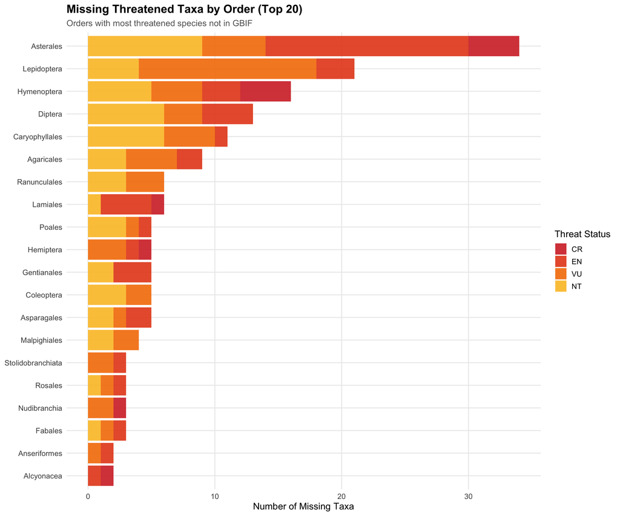

```r
if (exists("missing_threatened") && !is.null(missing_threatened) && nrow(missing_threatened) > 0 && "order" %in% names(missing_threatened)) {
  # Summarize missing by order
  missing_by_order <- missing_threatened |>
    filter(!is.na(order), order != "") |>
    group_by(order, threatStatus) |>
    summarise(n = n(), .groups = "drop") |>
    mutate(threatStatus = factor(threatStatus, levels = c("CR", "EN", "VU", "NT")))

  # Get top 20 orders by total missing
  top_orders <- missing_by_order |>
    group_by(order) |>
    summarise(total = sum(n), .groups = "drop") |>
    arrange(desc(total)) |>
    slice_head(n = 20) |>
    pull(order)

  missing_by_order_top <- missing_by_order |>
    filter(order %in% top_orders)

  if (nrow(missing_by_order_top) > 0) {
    print(ggplot(missing_by_order_top, aes(x = fct_reorder(order, n, .fun = sum), y = n, fill = threatStatus)) +
      geom_col(alpha = 0.9) +
      coord_flip() +
      scale_fill_manual(values = threat_colors, name = "Threat Status") +
      labs(
        title = "Missing Threatened Taxa by Order (Top 20)",
        subtitle = "Orders with most threatened species not in GBIF",
        x = NULL, y = "Number of Missing Taxa"
      ) +
      theme(legend.position = "right"))
  }
}
```

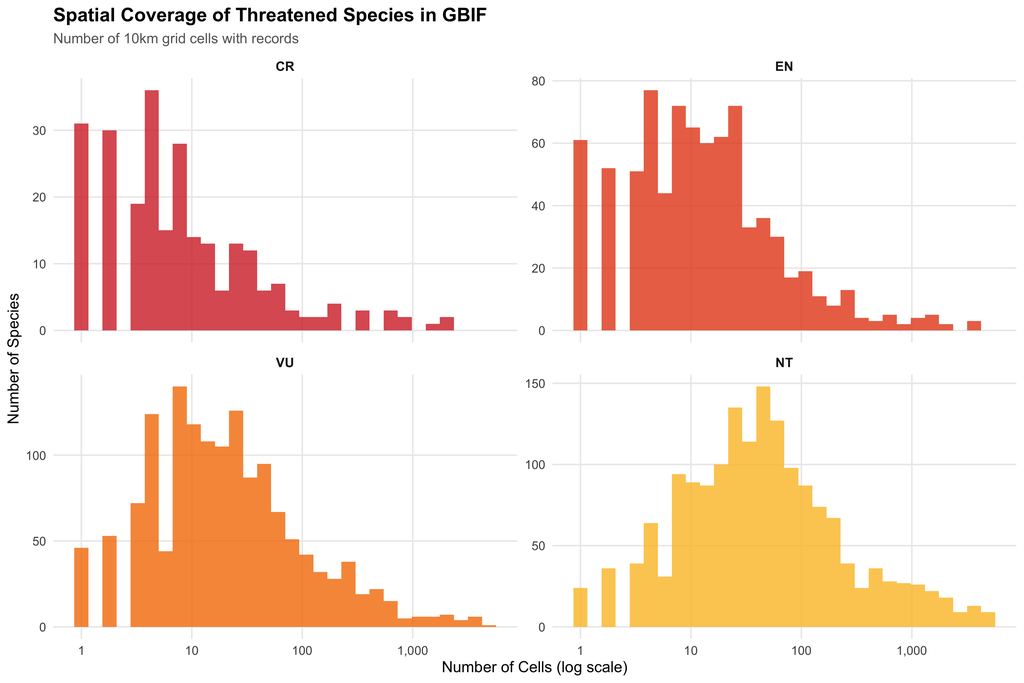

```r
# For threatened species that ARE in GBIF, how well are they covered spatially?
if (!is.null(threatened_summary) && nrow(threatened_summary) > 0) {
  # We need spatial data - check if it's in match_summary or load separately

  spatial_data <- safe_read(here(p_gaps, "taxonomic_spatial_coverage.csv"))

  if (!is.null(spatial_data) && nrow(spatial_data) > 0) {
    # Prepare threatened summary with only needed columns
    threatened_for_join <- threatened_summary |>
      filter(matched_any, threatStatus %in% c("CR", "EN", "VU", "NT")) |>
      select(any_of(c("scientificName", "scientific_std", "threatStatus")))

    if (nrow(threatened_for_join) > 0) {
      # Store threat status before join
      threat_lookup <- threatened_for_join |>
        select(any_of(c("scientificName", "scientific_std", "threatStatus"))) |>
        distinct()

      # Try to match on scientific name
      if ("scientificName" %in% names(spatial_data) && "scientificName" %in% names(threat_lookup)) {
        # Remove threatStatus from spatial_data if present to avoid conflicts
        spatial_cols <- setdiff(names(spatial_data), "threatStatus")
        threatened_spatial <- spatial_data |>
          select(all_of(spatial_cols)) |>
          inner_join(threat_lookup, by = "scientificName")
      } else if ("scientific_std" %in% names(spatial_data) && "scientific_std" %in% names(threat_lookup)) {
        spatial_cols <- setdiff(names(spatial_data), "threatStatus")
        threatened_spatial <- spatial_data |>
          select(all_of(spatial_cols)) |>
          inner_join(threat_lookup, by = "scientific_std")
      } else {
        threatened_spatial <- data.frame()
      }

      if (nrow(threatened_spatial) > 0 && "n_cells_10km" %in% names(threatened_spatial) && "threatStatus" %in% names(threatened_spatial)) {
        threatened_spatial <- threatened_spatial |>
          filter(n_cells_10km > 0) |>
          mutate(threatStatus = factor(threatStatus, levels = c("CR", "EN", "VU", "NT")))

        if (nrow(threatened_spatial) > 0) {
          print(ggplot(threatened_spatial, aes(x = n_cells_10km, fill = threatStatus)) +
            geom_histogram(bins = 30, alpha = 0.8) +
            facet_wrap(~threatStatus, scales = "free_y", ncol = 2) +
            scale_fill_manual(values = threat_colors) +
            scale_x_log10(labels = comma) +
            labs(
              title = "Spatial Coverage of Threatened Species in GBIF",
              subtitle = "Number of 10km grid cells with records",
              x = "Number of Cells (log scale)", y = "Number of Species"
            ) +
            theme(legend.position = "none"))
        } else {
          cat("No threatened species with spatial coverage data after filtering.\n")
        }
      } else {
        cat("No spatial coverage data available for threatened species.\n")
      }
    } else {
      cat("No threatened species (CR/EN/VU/NT) found in GBIF.\n")
    }
  } else {
    cat("Spatial coverage file not found.\n")
  }
}
```

# 3. Coverage by Higher Taxonomy

## 3.1 Coverage by Order

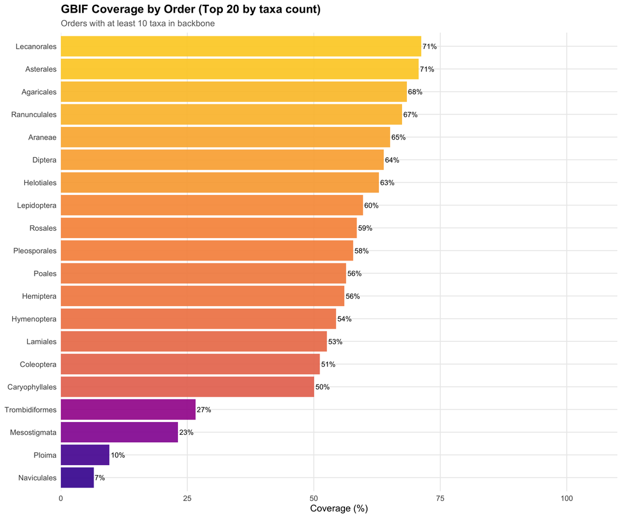

```r
tax_by_order <- safe_read(here(p_tables, "overview_taxonomic_gaps_by_order.csv"))

if (!is.null(tax_by_order) && nrow(tax_by_order) > 0) {
  order_plot <- tax_by_order |>
    filter(!is.na(order), order != "", n_taxa >= 10) |>
    arrange(desc(n_taxa)) |>
    slice_head(n = 20)

  if (nrow(order_plot) > 0 && "pct_coverage" %in% names(order_plot)) {
    ggplot(order_plot, aes(x = fct_reorder(order, pct_coverage),
                            y = pct_coverage, fill = pct_coverage)) +
      geom_col(alpha = 0.9) +
      geom_text(aes(label = paste0(round(pct_coverage, 0), "%")), hjust = -0.1, size = 3.5) +
      coord_flip() +
      scale_fill_viridis_c(option = "plasma", begin = 0.1, end = 0.9) +
      scale_y_continuous(limits = c(0, 110), expand = expansion(mult = c(0, 0))) +
      labs(
        title = "GBIF Coverage by Order (Top 20 by taxa count)",
        subtitle = "Orders with at least 10 taxa in backbone",
        x = NULL, y = "Coverage (%)"
      ) +
      theme(legend.position = "none")
  } else {
    cat("Order coverage data available but missing pct_coverage column.\n")
    order_plot |>
      select(any_of(c("order", "n_taxa", "n_in_gbif", "n_missing"))) |>
      kable(caption = "Order Coverage Data")
  }
} else {
  cat("Order coverage file not found or empty.\n")
}
```

## 3.2 Coverage by Family

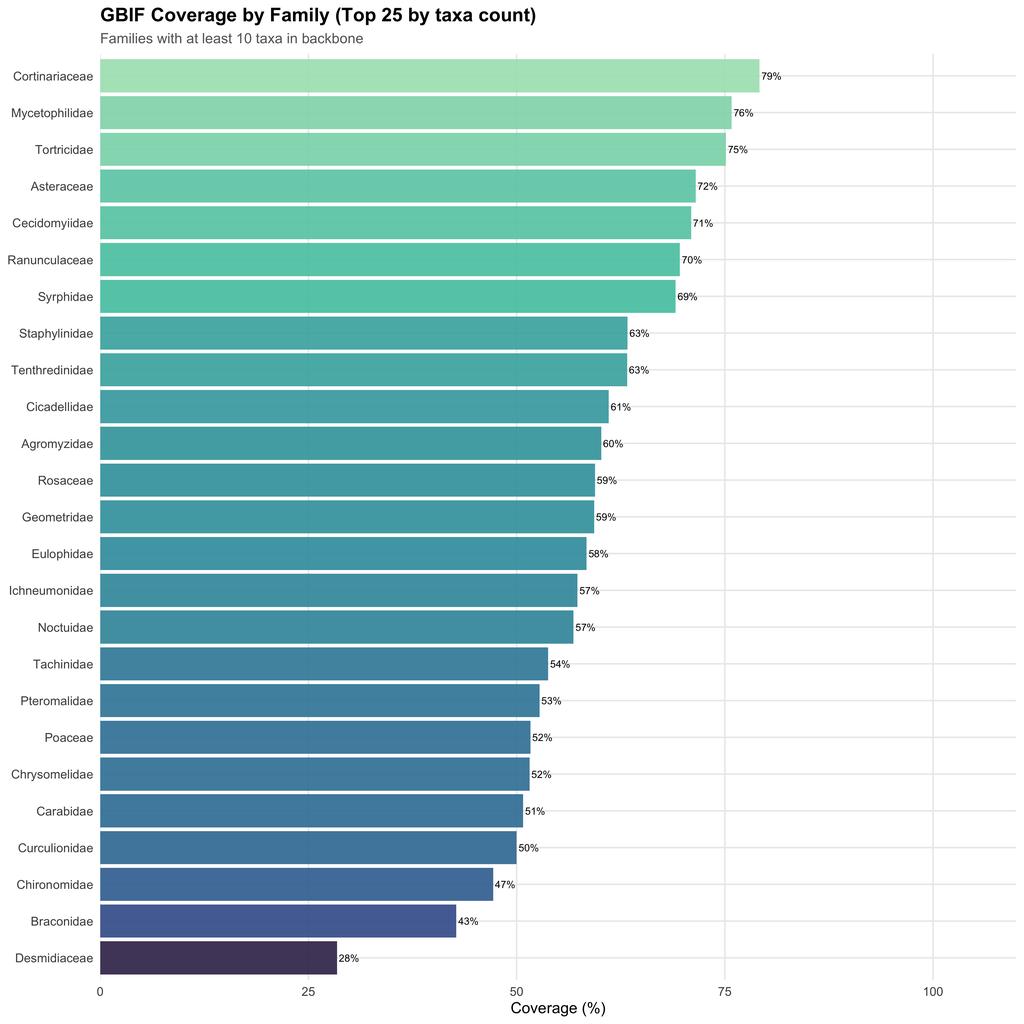

```r
tax_by_family <- safe_read(here(p_tables, "overview_taxonomic_gaps_by_family.csv"))

if (!is.null(tax_by_family) && nrow(tax_by_family) > 0) {
  family_plot <- tax_by_family |>
    filter(!is.na(family), family != "", n_taxa >= 10) |>
    arrange(desc(n_taxa)) |>
    slice_head(n = 25)

  if (nrow(family_plot) > 0 && "pct_coverage" %in% names(family_plot)) {
    ggplot(family_plot, aes(x = fct_reorder(family, pct_coverage),
                             y = pct_coverage, fill = pct_coverage)) +
      geom_col(alpha = 0.9) +
      geom_text(aes(label = paste0(round(pct_coverage, 0), "%")), hjust = -0.1, size = 3) +
      coord_flip() +
      scale_fill_viridis_c(option = "mako", begin = 0.2, end = 0.9) +
      scale_y_continuous(limits = c(0, 110), expand = expansion(mult = c(0, 0))) +
      labs(
        title = "GBIF Coverage by Family (Top 25 by taxa count)",
        subtitle = "Families with at least 10 taxa in backbone",
        x = NULL, y = "Coverage (%)"
      ) +
      theme(legend.position = "none")
  } else {
    cat("Family coverage data available but missing pct_coverage column.\n")
    family_plot |>
      select(any_of(c("family", "n_taxa", "n_in_gbif", "n_missing"))) |>
      kable(caption = "Family Coverage Data")
  }
} else {
  cat("Family coverage file not found or empty.\n")
}
```

# 4. Data Mobilization Trends

## 4.1 Top 10 Orders by Phylum (5-Year Trends)

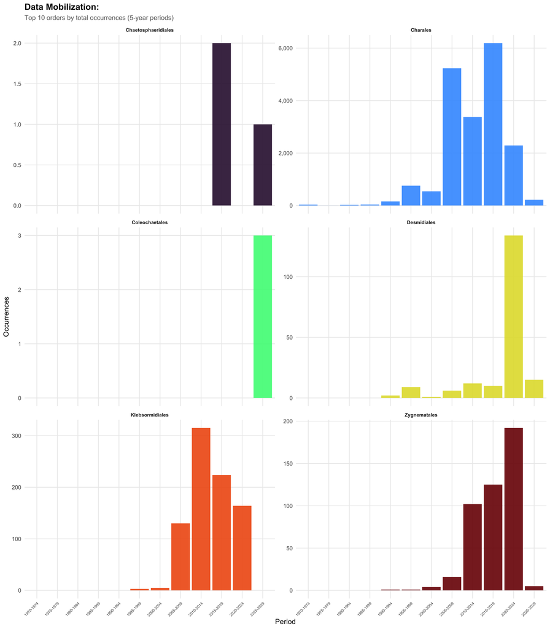

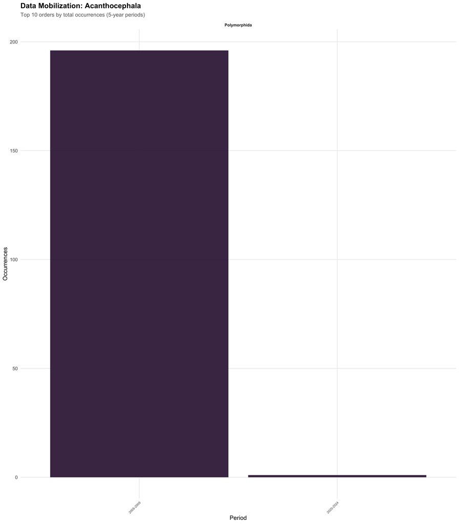

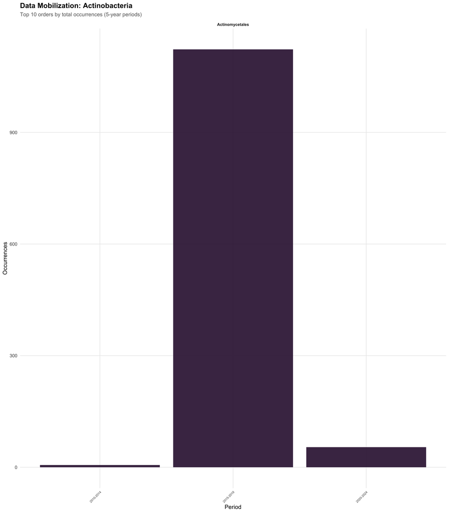

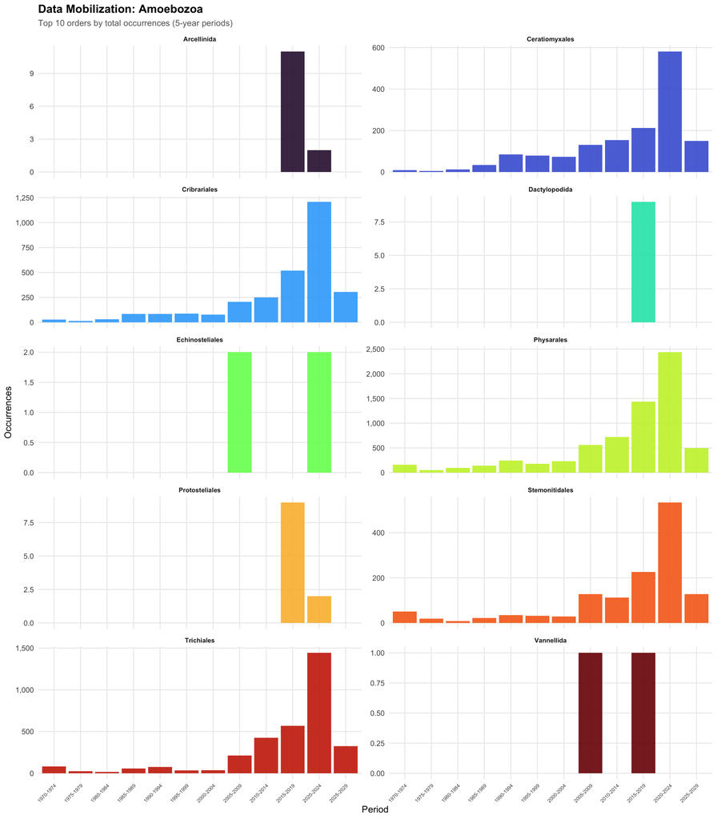

```r
order_temporal <- safe_read(here(p_integrated, "order_temporal_trends.csv"))

if (!is.null(order_temporal) && nrow(order_temporal) > 0) {
  # Get phylum info - try to join with match data
  if (!is.null(tax_match)) {
    phylum_lookup <- tax_match |>
      filter(!is.na(order), !is.na(phylum)) |>
      select(order, phylum) |>
      distinct()

    order_with_phylum <- order_temporal |>
      filter(grid == "grid10km") |>
      left_join(phylum_lookup, by = "order")
  } else {
    # If no match data, try to get phylum from order_temporal if available
    order_with_phylum <- order_temporal |>
      filter(grid == "grid10km")
    if (!"phylum" %in% names(order_with_phylum)) {
      order_with_phylum$phylum <- "Unknown"
    }
  }

  # Aggregate to 5-year periods
  order_5yr <- order_with_phylum |>
    filter(year >= 1970) |>
    mutate(period = paste0(floor(year / 5) * 5, "-", floor(year / 5) * 5 + 4)) |>
    group_by(phylum, order, period) |>
    summarise(occurrences = sum(as.numeric(total_occurrences), na.rm = TRUE), .groups = "drop")

  # Get top 10 orders per phylum
  top_orders_by_phylum <- order_5yr |>
    group_by(phylum, order) |>
    summarise(total = sum(as.numeric(occurrences)), .groups = "drop") |>
    group_by(phylum) |>
    arrange(desc(total)) |>
    slice_head(n = 10) |>
    ungroup()

  # Filter to top orders and plot
  order_5yr_top <- order_5yr |>
    inner_join(top_orders_by_phylum |> select(phylum, order), by = c("phylum", "order"))

  # Get unique phyla with data
  phyla_with_data <- unique(order_5yr_top$phylum)
  phyla_with_data <- phyla_with_data[!is.na(phyla_with_data) & phyla_with_data != "Unknown"]

  if (length(phyla_with_data) > 0) {
    # Plot for each major phylum
    for (phy in phyla_with_data[1:min(4, length(phyla_with_data))]) {
      phy_data <- order_5yr_top |> filter(phylum == phy)

      if (nrow(phy_data) > 0) {
        p <- ggplot(phy_data, aes(x = period, y = occurrences, fill = order)) +
          geom_col(alpha = 0.9) +
          facet_wrap(~order, scales = "free_y", ncol = 2) +
          scale_fill_viridis_d(option = "turbo") +
          scale_y_continuous(labels = comma) +
          labs(
            title = glue("Data Mobilization: {phy}"),
            subtitle = "Top 10 orders by total occurrences (5-year periods)",
            x = "Period", y = "Occurrences"
          ) +
          theme(
            axis.text.x = element_text(angle = 45, hjust = 1, size = 7),
            legend.position = "none",
            strip.text = element_text(size = 9)
          )
        print(p)
      }
    }
  } else {
    cat("No phylum data available for orders.\n")
  }
} else {
  cat("Order temporal trends file not found.\n")
}
```

## 4.2 Recent vs Historical Change

```
## Deriving top orders from temporal data...
```

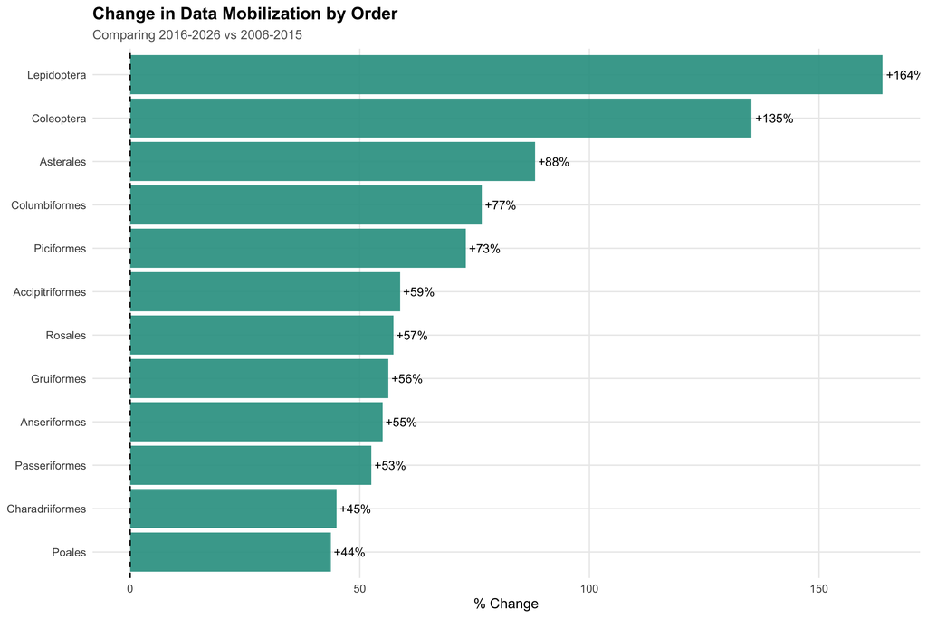

```r
top_orders <- safe_read(here(p_integrated, "top_orders.csv"))

# If order_temporal exists from section 4.1, use it
if (!is.null(order_temporal) && nrow(order_temporal) > 0) {

  # If top_orders file doesn't exist, derive from order_temporal
  if (is.null(top_orders) || nrow(top_orders) == 0) {
    cat("Deriving top orders from temporal data...\n\n")
    top_orders <- order_temporal |>
      filter(grid == "grid10km") |>
      group_by(order) |>
      summarise(total = sum(as.numeric(total_occurrences), na.rm = TRUE), .groups = "drop") |>
      arrange(desc(total)) |>
      slice_head(n = 12)
  }

  if (nrow(top_orders) > 0) {
    recent_cutoff <- current_year - 10
    historical_cutoff <- current_year - 20

    top_order_names <- top_orders$order[1:min(12, nrow(top_orders))]

    order_change <- order_temporal |>
      filter(order %in% top_order_names, grid == "grid10km") |>
      mutate(
        era = case_when(
          year >= recent_cutoff ~ "Recent",
          year >= historical_cutoff ~ "Historical",
          TRUE ~ NA_character_
        )
      ) |>
      filter(!is.na(era))

    if (nrow(order_change) > 0) {
      order_change_agg <- order_change |>
        group_by(order, era) |>
        summarise(occ = sum(as.numeric(total_occurrences), na.rm = TRUE), .groups = "drop")

      order_change_wide <- order_change_agg |>
        pivot_wider(names_from = era, values_from = occ, values_fill = 0)

      # Check if both columns exist
      if ("Recent" %in% names(order_change_wide) && "Historical" %in% names(order_change_wide)) {
        order_change_wide <- order_change_wide |>
          filter(Historical > 0) |>  # Avoid division by zero
          mutate(
            pct_change = 100 * (Recent - Historical) / Historical,
            direction = if_else(pct_change >= 0, "Increased", "Decreased")
          ) |>
          arrange(desc(pct_change))

        if (nrow(order_change_wide) > 0) {
          # Create label positions
          order_change_wide <- order_change_wide |>
            mutate(
              label_hjust = if_else(pct_change >= 0, -0.1, 1.1),
              label = paste0(if_else(pct_change >= 0, "+", ""), round(pct_change, 0), "%")
            )

          ggplot(order_change_wide, aes(x = fct_reorder(order, pct_change),
                                         y = pct_change, fill = direction)) +
            geom_col(alpha = 0.9) +
            geom_text(aes(label = label, hjust = label_hjust), size = 4) +
            coord_flip() +
            scale_fill_manual(values = c("Increased" = "#2A9D8F", "Decreased" = "#E76F51")) +
            geom_hline(yintercept = 0, linetype = "dashed") +
            labs(
              title = "Change in Data Mobilization by Order",
              subtitle = glue("Comparing {recent_cutoff}-{current_year} vs {historical_cutoff}-{recent_cutoff - 1}"),
              x = NULL, y = "% Change"
            ) +
            theme(legend.position = "none")
        } else {
          cat("No orders with historical data (before ", historical_cutoff, ") found.\n")
        }
      } else {
        cat("Missing Recent or Historical era data.\n")
        cat("Available eras: ", paste(names(order_change_wide), collapse = ", "), "\n")
      }
    } else {
      cat("No data within the specified time ranges.\n")
      cat("Recent cutoff: ", recent_cutoff, ", Historical cutoff: ", historical_cutoff, "\n")
      cat("Year range in data: ", min(order_temporal$year, na.rm = TRUE), " - ", max(order_temporal$year, na.rm = TRUE), "\n")
    }
  } else {
    cat("No top orders available.\n")
  }
} else {
  cat("Order temporal trends file not found or empty.\n")
  cat("Expected location: ", here(p_integrated, "order_temporal_trends.csv"), "\n")
}
```

# 5. Priority Taxa

Priority taxa are species that should be targeted for data collection efforts. These include: - Threatened species (CR, EN, VU, NT) missing from GBIF - Threatened species with poor spatial coverage in GBIF

## 5.1 Overview

```r
# Try to load priority_taxa file first
priority_taxa <- safe_read(here(p_integrated, "priority_taxa_all.csv"))

# If not available, derive from threatened_summary (from section 2)
if ((is.null(priority_taxa) || nrow(priority_taxa) == 0) && exists("threatened_summary") && !is.null(threatened_summary)) {
  cat("Deriving priority taxa from threatened species analysis...\n\n")

  # Priority = threatened species missing from GBIF or with poor coverage
  priority_taxa <- threatened_summary |>
    filter(threatStatus %in% c("CR", "EN", "VU", "NT")) |>
    filter(!matched_any) |>  # Missing from GBIF
    mutate(priority_reason = "Missing from GBIF")
}

if (!is.null(priority_taxa) && nrow(priority_taxa) > 0) {
  cat(glue("**{comma(nrow(priority_taxa))} taxa** require priority attention.\n\n"))

  # Check for threatStatus column
 threat_col <- intersect(c("threatStatus", "threatStatus_redlist", "threatStatus_backbone"), names(priority_taxa))[1]

  if (!is.na(threat_col)) {
    priority_taxa <- priority_taxa |>
      mutate(threatStatus = .data[[threat_col]])

    priority_by_threat <- priority_taxa |>
      filter(!is.na(threatStatus), threatStatus != "") |>
      group_by(threatStatus) |>
      summarise(n = n(), .groups = "drop") |>
      filter(threatStatus %in% c("CR", "EN", "VU", "NT", "LC")) |>
      arrange(match(threatStatus, c("CR", "EN", "VU", "NT", "LC")))

    if (nrow(priority_by_threat) > 0) {
      for (i in 1:nrow(priority_by_threat)) {
        cat(glue("- **{priority_by_threat$threatStatus[i]}**: {priority_by_threat$n[i]} taxa\n\n"))
      }
    }
  } else {
    cat("No threat status column found in priority taxa.\n")
  }
} else {
  cat("No priority taxa identified.\n")
  cat("This could mean:\n")
  cat("- All threatened species are already in GBIF, or\n
")
  cat("- No threatened species data is available in the reference taxonomy\n")
}
```

```
## **206 taxa** require priority attention.
## - **CR**: 17 taxa
## - **EN**: 49 taxa
## - **VU**: 71 taxa
## - **NT**: 69 taxa
```

## 5.2 Highest Priority (CR/EN)

```r
if (!is.null(priority_taxa) && nrow(priority_taxa) > 0 && "threatStatus" %in% names(priority_taxa)) {
  cr_en_priority <- priority_taxa |>
    filter(threatStatus %in% c("CR", "EN"))

  if (nrow(cr_en_priority) > 0) {
    cat(glue("**{nrow(cr_en_priority)} Critically Endangered and Endangered taxa** are priority for data mobilization.\n\n"))

    cr_en_priority |>
      select(any_of(c("scientificName", "threatStatus", "taxonRank", "family", "order", "class", "priority_reason"))) |>
      arrange(threatStatus, order, family, scientificName) |>
      slice_head(n = 50) |>
      kable(caption = "Priority CR/EN Taxa (First 50)")
  } else {
    cat("No CR/EN taxa in priority list - all may already be in GBIF.\n")
  }
} else {
  cat("No priority taxa data available.\n")
}
```

```
## **66 Critically Endangered and Endangered taxa** are priority for data mobilization.
```

Priority CR/EN Taxa (First 50)

| scientificName | threatStatus | taxonRank | family | order |
| --- | --- | --- | --- | --- |
| Anthothela grandiflora | CR | species | Anthothelidae | Alcyonacea |
| Phocoena phocoena (Baltic population) | CR | unranked | Phocoenidae | Artiodactyla |
| Hieracium femsioënse | CR | species | Asteraceae | Asterales |
| Hieracium toerense | CR | species | Asteraceae | Asterales |
| Taraxacum bavaricum | CR | species | Asteraceae | Asterales |
| Taraxacum tortilobum | CR | species | Asteraceae | Asterales |
| Calidris alpina schinzii | CR | subspecies | Scolopacidae | Charadriiformes |
| Aelia rostrata | CR | species | Pentatomidae | Hemiptera |
| Andrena morawitzi | CR | species | Andrenidae | Hymenoptera |
| Halictus quadricinctus | CR | species | Halictidae | Hymenoptera |
| Sphecodes spinulosus | CR | species | Halictidae | Hymenoptera |
| Evagetes gibbulus | CR | species | Pompilidae | Hymenoptera |
| Orobanche purpurea | CR | species | Orobanchaceae | Lamiales |
| Cetrelia olivetorum s.lat. | CR | speciesAggregate | Parmeliaceae | Lecanorales |
| Paracoryphella parva | CR | species | Paracoryphellidae | Nudibranchia |
| Lobaria amplissima | CR | species | Lobariaceae | Peltigerales |
| Tortula randii | CR | species | Pottiaceae | Pottiales |
| Cortinarius saporatus | EN | species | Cortinariaceae | Agaricales |
| Hygrophorus calophyllus | EN | species | Hygrophoraceae | Agaricales |
| Paramuricea placomus | EN | species | Plexauridae | Alcyonacea |
| Clangula hyemalis (wintering) | EN | unranked | Anatidae | Anseriformes |
| Dactylorhiza majalis subsp. baltica | EN | subspecies | Orchidaceae | Asparagales |
| Dactylorhiza majalis subsp. elatior | EN | subspecies | Orchidaceae | Asparagales |
| Centaurea phrygia subsp. phrygia | EN | subspecies | Asteraceae | Asterales |
| Hieracium cacuminatum | EN | species | Asteraceae | Asterales |
| Hieracium carcarophyllum | EN | species | Asteraceae | Asterales |
| Hieracium haboënse | EN | species | Asteraceae | Asterales |
| Hieracium hastato-ovatum | EN | species | Asteraceae | Asterales |
| Hieracium helenae | EN | species | Asteraceae | Asterales |
| Hieracium imbricatum | EN | species | Asteraceae | Asterales |
| Hieracium maculosiforme | EN | species | Asteraceae | Asterales |
| Hieracium marginelliceps | EN | species | Asteraceae | Asterales |
| Hieracium oreades | EN | species | Asteraceae | Asterales |
| Hieracium planifrons | EN | species | Asteraceae | Asterales |
| Hieracium pseudonosmoides | EN | species | Asteraceae | Asterales |
| Hieracium pycnodon | EN | species | Asteraceae | Asterales |
| Hieracium remanentiforme | EN | species | Asteraceae | Asterales |
| Taraxacum biformatum | EN | species | Asteraceae | Asterales |
| Taraxacum dilutisquameum | EN | species | Asteraceae | Asterales |
| Canis lupus lupus | EN | subspecies | Canidae | Carnivora |
| Stellaria crassifolia var. minor | EN | variety | Caryophyllaceae | Caryophyllales |
| Philine punctata | EN | species | Philinidae | Cephalaspidea |
| Choerades lapponicus | EN | species | Asilidae | Diptera |
| Systenus tener | EN | species | Dolichopodidae | Diptera |
| Blera eoa | EN | species | Syrphidae | Diptera |
| Caliprobola speciosa | EN | species | Syrphidae | Diptera |
| Polygala vulgaris subsp. collina | EN | subspecies | Polygalaceae | Fabales |
| Centaurium erythraea var. capitatum | EN | variety | Gentianaceae | Gentianales |
| Gentianella campestris subsp. baltica | EN | subspecies | Gentianaceae | Gentianales |
| Gentianella campestris subsp. campestris | EN | subspecies | Gentianaceae | Gentianales |

## 5.3 Priority by Family

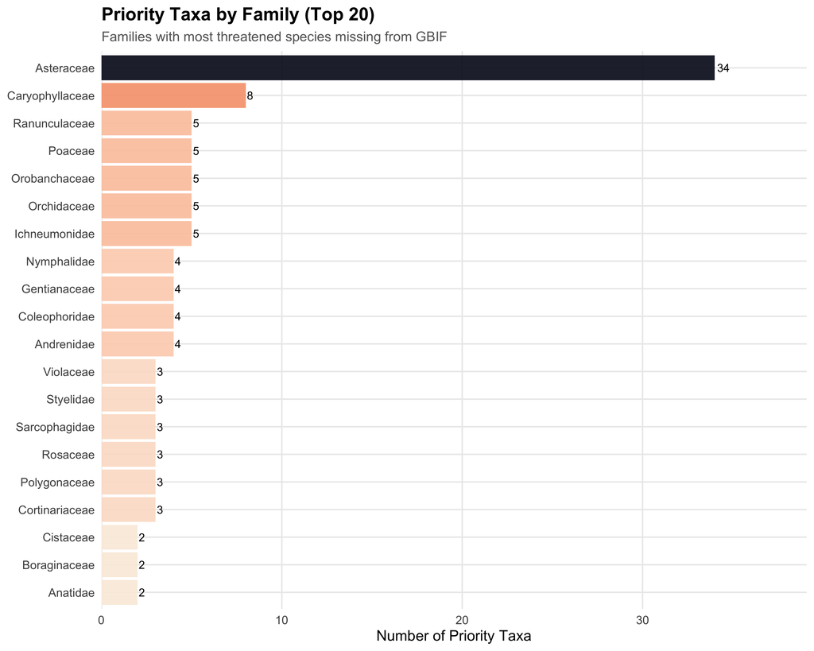

```r
if (!is.null(priority_taxa) && nrow(priority_taxa) > 0 && "family" %in% names(priority_taxa)) {
  priority_by_family <- priority_taxa |>
    filter(!is.na(family), family != "") |>
    group_by(family) |>
    summarise(n = n(), .groups = "drop") |>
    arrange(desc(n)) |>
    slice_head(n = 20)

  if (nrow(priority_by_family) > 0) {
    ggplot(priority_by_family, aes(x = fct_reorder(family, n), y = n, fill = n)) +
      geom_col(alpha = 0.9) +
      geom_text(aes(label = n), hjust = -0.2, size = 3.5) +
      coord_flip() +
      scale_fill_viridis_c(option = "rocket", direction = -1) +
      scale_y_continuous(expand = expansion(mult = c(0, 0.15))) +
      labs(
        title = "Priority Taxa by Family (Top 20)",
        subtitle = "Families with most threatened species missing from GBIF",
        x = NULL, y = "Number of Priority Taxa"
      ) +
      theme(legend.position = "none")
  } else {
    cat("No family data available for priority taxa.\n")
  }
} else {
  cat("No priority taxa with family information available.\n")
}
```

## 5.4 Priority by Order

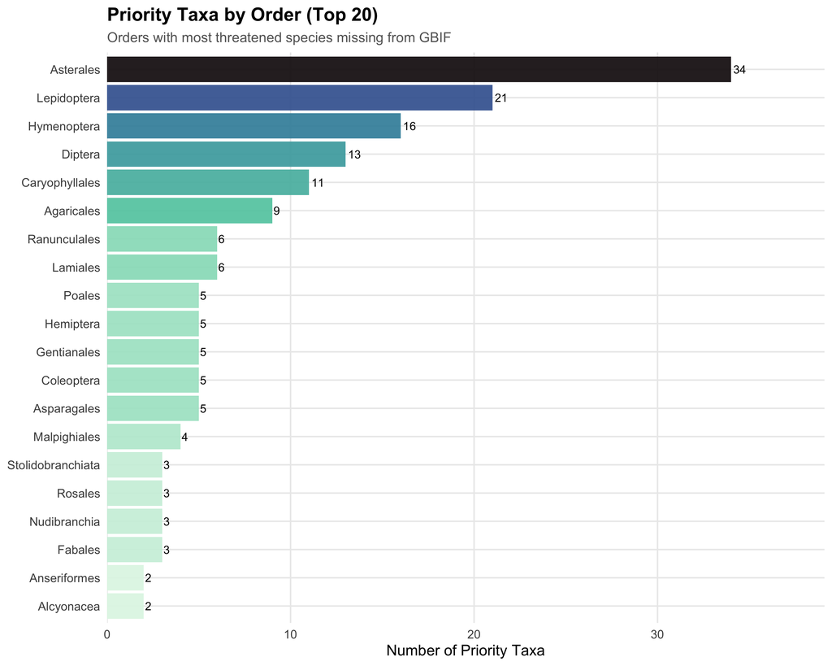

```r
if (!is.null(priority_taxa) && nrow(priority_taxa) > 0 && "order" %in% names(priority_taxa)) {
  priority_by_order <- priority_taxa |>
    filter(!is.na(order), order != "") |>
    group_by(order) |>
    summarise(n = n(), .groups = "drop") |>
    arrange(desc(n)) |>
    slice_head(n = 20)

  if (nrow(priority_by_order) > 0) {
    ggplot(priority_by_order, aes(x = fct_reorder(order, n), y = n, fill = n)) +
      geom_col(alpha = 0.9) +
      geom_text(aes(label = n), hjust = -0.2, size = 3.5) +
      coord_flip() +
      scale_fill_viridis_c(option = "mako", direction = -1) +
      scale_y_continuous(expand = expansion(mult = c(0, 0.15))) +
      labs(
        title = "Priority Taxa by Order (Top 20)",
        subtitle = "Orders with most threatened species missing from GBIF",
        x = NULL, y = "Number of Priority Taxa"
      ) +
      theme(legend.position = "none")
  } else {
    cat("No order data available for priority taxa.\n")
  }
} else {
  cat("No priority taxa with order information available.\n")
}
```

# 6. Summary & Recommendations

```r
cat("## Key Findings\n\n")
```

## Key Findings

```r
if (!is.null(dashboard)) {
  cat(glue("- **Overall coverage**: {dashboard$taxa_pct_coverage}% ({comma(dashboard$taxa_in_gbif)} of {comma(dashboard$taxa_in_reference)} taxa)"), "\n\n")
}
```

- **Overall coverage**: 48.3% (53,150 of 110,010 taxa)

```r
if (!is.null(missing_threatened) && nrow(missing_threatened) > 0) {
  n_cr <- sum(missing_threatened$threatStatus == "CR", na.rm = TRUE)
  n_en <- sum(missing_threatened$threatStatus == "EN", na.rm = TRUE)
  cat(glue("- **Missing threatened taxa**: {comma(nrow(missing_threatened))}"), "\n")
  cat(glue("  - CR: {n_cr}, EN: {n_en}"), "\n\n")
}
```

- **Missing threatened taxa**: 206
  - CR: 17, EN: 49

```r
if (!is.null(priority_taxa) && nrow(priority_taxa) > 0) {
  cat(glue("- **Priority taxa**: {comma(nrow(priority_taxa))}"), "\n\n")
}
```

- **Priority taxa**: 206

```r
cat("\n## Recommendations\n\n")
```

## Recommendations

```r
cat("1. **Highest priority**: Focus on CR and EN species missing from GBIF\n\n")
```

1. **Highest priority**: Focus on CR and EN species missing from GBIF

```r
cat("2. **Target underrepresented families** for systematic surveys\n\n")
```

2. **Target underrepresented families** for systematic surveys

```r
cat("3. **Digitize museum specimens** for poorly covered taxonomic groups\n\n")
```

3. **Digitize museum specimens** for poorly covered taxonomic groups

```r
cat("4. **Maintain mobilization momentum** for orders showing growth\n\n")
```

4. **Maintain mobilization momentum** for orders showing growth

```r
cat("5. **Investigate declining orders** and address data collection gaps\n\n")
```

5. **Investigate declining orders** and address data collection gaps

# 6. Last 12 Months Highlights

```r
order_temporal_ly <- safe_read(here(p_integrated, "order_temporal_trends.csv"))
time_summary_tax <- safe_read(here(p_derived, "time_summary_10km.csv"))

recent_cutoff_ym <- NULL
recent_label <- NULL

if (!is.null(time_summary_tax)) {
  ts_t <- time_summary_tax |> as_tibble() |>
    filter(basisofrecord == "all") |>
    mutate(yearmonth_int = as.integer(gsub("-", "", yearmonth)))

  all_ym <- sort(unique(ts_t$yearmonth_int))
  if (length(all_ym) > 0) {
    latest_ym <- max(all_ym)
    latest_year <- as.integer(substr(as.character(latest_ym), 1, 4))
    latest_month <- as.integer(substr(as.character(latest_ym), 5, 6))
    cutoff_date <- as.Date(paste0(latest_year, "-", sprintf("%02d", latest_month), "-01")) %m-% months(11)
    recent_cutoff_ym <- as.integer(format(cutoff_date, "%Y%m"))
    recent_label <- paste0(format(cutoff_date, "%b %Y"), " – ",
      format(as.Date(paste0(latest_year, "-", sprintf("%02d", latest_month), "-01")), "%b %Y"))
  }
}
if (is.null(recent_cutoff_ym)) {
  recent_cutoff_ym <- as.integer(paste0(year(Sys.Date()) - 1, "01"))
  recent_label <- paste0(year(Sys.Date()) - 1)
}
ly_label <- recent_label
cutoff_year <- as.integer(substr(as.character(recent_cutoff_ym), 1, 4))
```

## 6.1 Taxonomic Bias: Recent Contribution

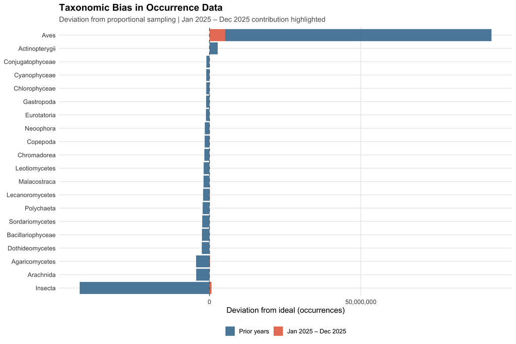

```r
if (!is.null(match_summary) && !is.null(order_temporal_ly)) {
  order_to_class <- match_summary |> as_tibble() |>
    filter(!is.na(class), class != "", !is.na(order), order != "") |>
    distinct(kingdom, phylum, class, order)

  known_cls <- match_summary |> as_tibble() |>
    filter(!is.na(class), class != "") |>
    group_by(kingdom, class) |>
    summarise(n_known = n(), .groups = "drop")

  occ_cls <- order_temporal_ly |> as_tibble() |>
    inner_join(order_to_class, by = "order") |>
    mutate(era = ifelse(year >= cutoff_year, "last_year", "prior")) |>
    group_by(kingdom, class, era) |>
    summarise(occ = sum(total_occurrences, na.rm = TRUE), .groups = "drop") |>
    pivot_wider(names_from = era, values_from = occ, values_fill = 0)

  if (!"prior" %in% names(occ_cls)) occ_cls$prior <- 0
  if (!"last_year" %in% names(occ_cls)) occ_cls$last_year <- 0

  troudet_rpt <- known_cls |>
    left_join(occ_cls, by = c("kingdom", "class")) |>
    mutate(prior = replace_na(prior, 0), last_year = replace_na(last_year, 0),
           total_occ = prior + last_year,
           total_known = sum(n_known),
           ideal = (n_known / total_known) * sum(total_occ),
           bias = total_occ - ideal) |>
    arrange(desc(abs(bias))) |> slice_head(n = 20)

  troudet_long <- troudet_rpt |>
    mutate(bias_prior = prior - ideal, bias_ly = last_year) |>
    select(class, bias_prior, bias_ly) |>
    pivot_longer(c(bias_prior, bias_ly), names_to = "era", values_to = "value") |>
    mutate(era = factor(era, levels = c("bias_prior", "bias_ly"),
                        labels = c("Prior years", ly_label)))

  ggplot(troudet_long, aes(x = value, y = fct_reorder(class, value, .fun = sum), fill = era)) +
    geom_col(alpha = 0.9) +
    geom_vline(xintercept = 0, linetype = "dashed", color = "grey40") +
    scale_fill_manual(values = c("Prior years" = "#457B9D", setNames("#E76F51", ly_label)),
                      name = NULL) +
    scale_x_continuous(labels = comma) +
    labs(title = "Taxonomic Bias in Occurrence Data",
         subtitle = paste0("Deviation from proportional sampling | ", ly_label, " contribution highlighted"),
         x = "Deviation from ideal (occurrences)", y = NULL) +
    theme(legend.position = "bottom")
}
```

## 6.2 Top Orders by Recent Activity

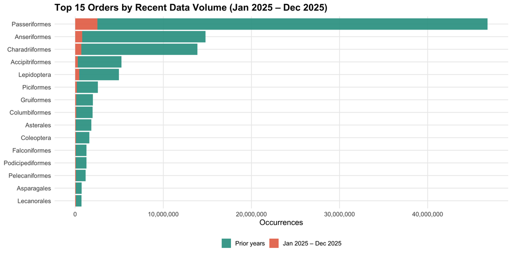

```r
if (!is.null(order_temporal_ly)) {
  ord_ly <- order_temporal_ly |> as_tibble() |>
    mutate(era = ifelse(year >= cutoff_year, "last_year", "prior")) |>
    group_by(order, era) |>
    summarise(occ = sum(total_occurrences, na.rm = TRUE), .groups = "drop") |>
    pivot_wider(names_from = era, values_from = occ, values_fill = 0)

  if (!"prior" %in% names(ord_ly)) ord_ly$prior <- 0
  if (!"last_year" %in% names(ord_ly)) ord_ly$last_year <- 0

  top_ord <- ord_ly |> arrange(desc(last_year)) |> slice_head(n = 15)

  top_long <- top_ord |>
    pivot_longer(c(prior, last_year), names_to = "era", values_to = "occ") |>
    mutate(era = factor(era, levels = c("prior", "last_year"),
                        labels = c("Prior years", ly_label)))

  ggplot(top_long, aes(x = occ, y = fct_reorder(order, occ, .fun = sum), fill = era)) +
    geom_col(alpha = 0.9) +
    scale_fill_manual(values = c("Prior years" = "#2A9D8F", setNames("#E76F51", ly_label)),
                      name = NULL) +
    scale_x_continuous(labels = comma) +
    labs(title = paste0("Top 15 Orders by Recent Data Volume (", ly_label, ")"),
         x = "Occurrences", y = NULL) +
    theme(legend.position = "bottom")
}
```